# 07_modelos_ml_con_regimenes

```python
# Vamos a preparar la data para el modelo de regimenes

import pandas as pd
import numpy as np
import requests, time

BASE_URL = "https://api.binance.com"
SYMBOL = "BTCUSDT"
INTERVAL = "5m"

START_DATE = "2024-12-01 00:00:00"
END_DATE   = "2025-11-24 23:55:00"

START_TS = int(pd.to_datetime(START_DATE, utc=True).timestamp() * 1000)
END_TS   = int(pd.to_datetime(END_DATE,   utc=True).timestamp() * 1000)

MAX_LIMIT = 1000

def download_klines_range(symbol, interval, start_ts, end_ts, verbose=True):
    url = f"{BASE_URL}/api/v3/klines"
    all_data = []
    next_start = start_ts

    if verbose:
        print(f"📡 Descargando {symbol} [{interval}] desde {START_DATE} hasta {END_DATE}")

    while True:
        params = {
            "symbol": symbol,
            "interval": interval,
            "limit": MAX_LIMIT,
            "startTime": next_start,
            "endTime": end_ts
        }
        r = requests.get(url, params=params, timeout=15)
        data = r.json()

        if not data or isinstance(data, dict):
            break

        all_data.extend(data)
        last_open_time = data[-1][0]
        next_start = last_open_time + 1

        if last_open_time >= end_ts or len(data) < MAX_LIMIT:
            break

        time.sleep(0.25)

    cols = [
        "Open time", "Open", "High", "Low", "Close", "Volume",
        "Close time", "Quote asset volume", "Number of trades",
        "Taker buy base asset volume", "Taker buy quote asset volume", "Ignore"
    ]

    df = pd.DataFrame(all_data, columns=cols)

    for c in ["Open", "High", "Low", "Close", "Volume"]:
        df[c] = pd.to_numeric(df[c], errors="coerce")

    df["Open time"]  = pd.to_datetime(df["Open time"], unit="ms", utc=True)
    df["Close time"] = pd.to_datetime(df["Close time"], unit="ms", utc=True)

    df = df.sort_values("Open time").reset_index(drop=True)
    return df

df_raw = download_klines_range(SYMBOL, INTERVAL, START_TS, END_TS, verbose=True)
df_raw.head(3)
```

```
📡 Descargando BTCUSDT [5m] desde 2024-12-01 00:00:00 hasta 2025-11-24 23:55:00
```

|  | Open time | Open | High | Low | Close | Volume | Close time | Quote asset volume | Number of trades | Taker buy base asset volume | Taker buy quote asset volume | Ignore |
| --- | --- | --- | --- | --- | --- | --- | --- | --- | --- | --- | --- | --- |
| 0 | 2024-12-01 00:00:00+00:00 | 96407.99 | 96524.00 | 96350.13 | 96508.29 | 35.87706 | 2024-12-01 00:04:59.999000+00:00 | 3459760.39953790 | 10233 | 19.01492000 | 1833852.07539100 | 0 |
| 1 | 2024-12-01 00:05:00+00:00 | 96508.29 | 96541.36 | 96485.94 | 96541.36 | 32.12217 | 2024-12-01 00:09:59.999000+00:00 | 3100054.94399220 | 8493 | 23.02962000 | 2222533.15192700 | 0 |
| 2 | 2024-12-01 00:10:00+00:00 | 96541.36 | 96584.00 | 96540.00 | 96566.33 | 30.77671 | 2024-12-01 00:14:59.999000+00:00 | 2971755.88219990 | 6247 | 16.65161000 | 1607876.78270910 | 0 |

```python
# Parámetros paper (BTCUSDT)
p = {"mom_win": 4, "speed_win": 9, "accel_win": 7, "zspeed_min": 0.3, "zaccel_min": 0.1}

def calcular_momentum_fisico_speed(df, mom_win, speed_win, accel_win):
    df = df.copy()

    # 1) Momentum
    df["mom"] = df["Close"].diff()
    df["mom_smooth"] = df["mom"].rolling(mom_win, min_periods=1).mean()

    # 2) Speed
    df["speed"] = df["mom_smooth"].diff()
    df["speed_smooth"] = df["speed"].rolling(speed_win, min_periods=1).median()

    # 3) Accel
    df["accel"] = df["speed_smooth"].diff()
    df["accel_smooth"] = df["accel"].rolling(accel_win, min_periods=1).median()

    # 4) Z-scores (ventana fija 30)
    std_speed = df["speed_smooth"].rolling(30).std().replace(0, np.nan)
    std_accel = df["accel_smooth"].rolling(30).std().replace(0, np.nan)

    df["zspeed"] = (df["speed_smooth"] / std_speed).fillna(0)
    df["zaccel"] = (df["accel_smooth"] / std_accel).fillna(0)

    return df.reset_index(drop=True)

df_feat = calcular_momentum_fisico_speed(df_raw, p["mom_win"], p["speed_win"], p["accel_win"])
df_feat[["Open time","Close","mom_smooth","speed_smooth","accel_smooth","zspeed","zaccel"]].head(10)
```

|  | Open time | Close | mom_smooth | speed_smooth | accel_smooth | zspeed | zaccel |
| --- | --- | --- | --- | --- | --- | --- | --- |
| 0 | 2024-12-01 00:00:00+00:00 | 96508.29 | NaN | NaN | NaN | 0.0 | 0.0 |
| 1 | 2024-12-01 00:05:00+00:00 | 96541.36 | 33.070000 | NaN | NaN | 0.0 | 0.0 |
| 2 | 2024-12-01 00:10:00+00:00 | 96566.33 | 29.020000 | -4.050000 | NaN | 0.0 | 0.0 |
| 3 | 2024-12-01 00:15:00+00:00 | 96553.61 | 15.106667 | -8.981667 | -4.931667 | 0.0 | 0.0 |
| 4 | 2024-12-01 00:20:00+00:00 | 96555.15 | 11.715000 | -4.050000 | 0.000000 | 0.0 | 0.0 |
| 5 | 2024-12-01 00:25:00+00:00 | 96601.41 | 15.012500 | -3.720833 | 0.329167 | 0.0 | 0.0 |
| 6 | 2024-12-01 00:30:00+00:00 | 96672.49 | 26.540000 | -3.391667 | 0.329167 | 0.0 | 0.0 |
| 7 | 2024-12-01 00:35:00+00:00 | 96487.82 | -16.447500 | -3.720833 | 0.329167 | 0.0 | 0.0 |
| 8 | 2024-12-01 00:40:00+00:00 | 96272.27 | -70.720000 | -4.050000 | 0.000000 | 0.0 | 0.0 |
| 9 | 2024-12-01 00:45:00+00:00 | 96415.21 | -46.550000 | -3.720833 | 0.329167 | 0.0 | 0.0 |

```python
def generar_senales_fisico(df, zspeed_min, zaccel_min):
    df = df.copy()

    df["buy_raw"] = (
        (df["zspeed"].shift(1) < 0) &
        (df["zspeed"] > zspeed_min) &
        (df["zaccel"] > zaccel_min)
    )

    df["sell_raw"] = (
        (df["zspeed"].shift(1) > 0) &
        (df["zspeed"] < -zspeed_min) &
        (df["zaccel"] < -zaccel_min)
    )

    in_pos = False
    BUY, SELL = [], []

    for i in range(len(df)):
        if bool(df.loc[i, "buy_raw"]) and not in_pos:
            BUY.append(True); SELL.append(False); in_pos = True
        elif bool(df.loc[i, "sell_raw"]) and in_pos:
            BUY.append(False); SELL.append(True); in_pos = False
        else:
            BUY.append(False); SELL.append(False)

    df["BUY"] = BUY
    df["SELL"] = SELL
    return df

df_signals = generar_senales_fisico(df_feat, p["zspeed_min"], p["zaccel_min"])

# df_viz = dataset final por vela (candles + features + señales)
cols_viz = [
    "Open time","Open","High","Low","Close","Volume",
    "mom","mom_smooth","speed","speed_smooth","accel","accel_smooth",
    "zspeed","zaccel","BUY","SELL"
]
df_viz = df_signals[cols_viz].copy()

print("BUY signals:", int(df_viz["BUY"].sum()))
print("SELL signals:", int(df_viz["SELL"].sum()))
df_viz.head(5)
```

```
BUY signals: 398
SELL signals: 398
```

|  | Open time | Open | High | Low | Close | Volume | mom | mom_smooth | speed | speed_smooth | accel | accel_smooth | zspeed | zaccel | BUY | SELL |
| --- | --- | --- | --- | --- | --- | --- | --- | --- | --- | --- | --- | --- | --- | --- | --- | --- |
| 0 | 2024-12-01 00:00:00+00:00 | 96407.99 | 96524.00 | 96350.13 | 96508.29 | 35.87706 | NaN | NaN | NaN | NaN | NaN | NaN | 0.0 | 0.0 | False | False |
| 1 | 2024-12-01 00:05:00+00:00 | 96508.29 | 96541.36 | 96485.94 | 96541.36 | 32.12217 | 33.07 | 33.070000 | NaN | NaN | NaN | NaN | 0.0 | 0.0 | False | False |
| 2 | 2024-12-01 00:10:00+00:00 | 96541.36 | 96584.00 | 96540.00 | 96566.33 | 30.77671 | 24.97 | 29.020000 | -4.050000 | -4.050000 | NaN | NaN | 0.0 | 0.0 | False | False |
| 3 | 2024-12-01 00:15:00+00:00 | 96566.33 | 96581.65 | 96515.12 | 96553.61 | 33.46560 | -12.72 | 15.106667 | -13.913333 | -8.981667 | -4.931667 | -4.931667 | 0.0 | 0.0 | False | False |
| 4 | 2024-12-01 00:20:00+00:00 | 96553.60 | 96595.77 | 96524.02 | 96555.15 | 24.24526 | 1.54 | 11.715000 | -3.391667 | -4.050000 | 4.931667 | 0.000000 | 0.0 | 0.0 | False | False |

```python
HYBRID_PAPER_CONFIG = {
    "regime_classifier": {
        "D": 6,
        "thr_pos_z": 0.55,
        "thr_early_mfe": 0.004,
        "thr_early_ret": 0.001,
    },
    "deterioration_exit": {
        "N_zspeed_neg": 2,
        "zaccel_thr": 0.0,
        "min_hold_bars": 0,
        "require_peak": True,
        "peak_gain_min": 0.002,
    }
}

# ========= helpers del dataset ML =========
def build_trade_pairs(df):
    df = df.reset_index(drop=True)
    buy_idx = df.index[df["BUY"]].to_list()
    sell_idx = df.index[df["SELL"]].to_list()
    n = min(len(buy_idx), len(sell_idx))
    return list(zip(buy_idx[:n], sell_idx[:n]))

def compute_early_features(df, entry_idx, D=6):
    start = entry_idx + 1
    end = min(entry_idx + D, len(df) - 1)
    g = df.loc[start:end].copy()

    entry_price = float(df.loc[entry_idx, "Close"])
    early_ret = float((g["Close"].iloc[-1] - entry_price) / entry_price)

    early_peak = float(g["High"].max())
    early_mfe = float((early_peak - entry_price) / entry_price)

    pos_zspeed_ratio = float((g["zspeed"] > 0).mean())

    zspeed_mean = float(g["zspeed"].mean())
    zspeed_std  = float(g["zspeed"].std(ddof=0))
    zaccel_mean = float(g["zaccel"].mean())
    zaccel_std  = float(g["zaccel"].std(ddof=0))

    t = np.arange(len(g))
    if len(g) > 1 and np.std(g["zspeed"].values) > 0:
        zspeed_slope = float(np.corrcoef(t, g["zspeed"].values)[0,1])
    else:
        zspeed_slope = 0.0

    hl_range_mean = float(((g["High"] - g["Low"]) / g["Close"]).mean())

    return {
        "early_ret": early_ret,
        "early_mfe": early_mfe,
        "pos_zspeed_ratio": pos_zspeed_ratio,
        "zspeed_mean": zspeed_mean,
        "zspeed_std": zspeed_std,
        "zaccel_mean": zaccel_mean,
        "zaccel_std": zaccel_std,
        "zspeed_slope": zspeed_slope,
        "hl_range_mean": hl_range_mean,
    }

def label_fragile_regime(early_feats, cfg):
    thr_pos_z     = cfg["regime_classifier"]["thr_pos_z"]
    thr_early_mfe = cfg["regime_classifier"]["thr_early_mfe"]
    thr_early_ret = cfg["regime_classifier"]["thr_early_ret"]

    return bool(
        (early_feats["pos_zspeed_ratio"] < thr_pos_z) or
        (early_feats["early_mfe"] < thr_early_mfe) or
        (early_feats["early_ret"] < thr_early_ret)
    )

def find_deterioration_exit(df, entry_idx, exit_idx_original, N_zspeed_neg, zaccel_thr, min_hold_bars,
                            require_peak=False, peak_gain_min=0.0):
    start = entry_idx + min_hold_bars
    if start > exit_idx_original:
        return exit_idx_original

    entry_price = float(df.loc[entry_idx, "Close"])

    for t in range(start, exit_idx_original + 1):

        if require_peak:
            peak_high = float(df.loc[entry_idx:t, "High"].max())
            if peak_high < entry_price * (1.0 + peak_gain_min):
                continue

        left = t - N_zspeed_neg + 1
        if left < entry_idx:
            continue

        if not (df.loc[left:t, "zspeed"] < 0).all():
            continue

        if float(df.loc[t, "zaccel"]) <= zaccel_thr:
            return t

    return exit_idx_original

def compute_trade_metrics(df, entry_idx, exit_idx):
    entry_price = float(df.loc[entry_idx, "Close"])
    exit_price  = float(df.loc[exit_idx, "Close"])
    exit_return = (exit_price - entry_price) / entry_price

    peak_high = float(df.loc[entry_idx:exit_idx, "High"].max())
    mfe = (peak_high - entry_price) / entry_price

    if peak_high > entry_price:
        giveback_ratio = (peak_high - exit_price) / (peak_high - entry_price)
    else:
        giveback_ratio = 0.0

    giveback_x_mfe = giveback_ratio * mfe
    return float(exit_return), float(mfe), float(giveback_ratio), float(giveback_x_mfe)

def build_ml_dataset(df_viz, cfg):
    pairs = build_trade_pairs(df_viz)

    rows = []
    for trade_id, (entry_idx, exit_idx_base) in enumerate(pairs):
        entry_time = df_viz.loc[entry_idx, "Open time"]
        entry_price = float(df_viz.loc[entry_idx, "Close"])

        # baseline metrics
        exit_time_base = df_viz.loc[exit_idx_base, "Open time"]
        exit_price_base = float(df_viz.loc[exit_idx_base, "Close"])
        ret_base, mfe_base, gb_base, gbxmfe_base = compute_trade_metrics(df_viz, entry_idx, exit_idx_base)

        # features early
        early_feats = compute_early_features(df_viz, entry_idx, D=cfg["regime_classifier"]["D"])
        fragile = label_fragile_regime(early_feats, cfg)

        # hybrid exit (teacher)
        det_cfg = cfg["deterioration_exit"]
        exit_idx_hyb = exit_idx_base
        used_deterioration = False
        exited_early = False

        if fragile:
            exit_idx_hyb = find_deterioration_exit(
                df_viz, entry_idx, exit_idx_base,
                N_zspeed_neg=det_cfg["N_zspeed_neg"],
                zaccel_thr=det_cfg["zaccel_thr"],
                min_hold_bars=det_cfg["min_hold_bars"],
                require_peak=det_cfg["require_peak"],
                peak_gain_min=det_cfg["peak_gain_min"],
            )
            used_deterioration = True
            exited_early = exit_idx_hyb < exit_idx_base

        exit_time_hyb = df_viz.loc[exit_idx_hyb, "Open time"]
        exit_price_hyb = float(df_viz.loc[exit_idx_hyb, "Close"])
        ret_hyb, mfe_hyb, gb_hyb, gbxmfe_hyb = compute_trade_metrics(df_viz, entry_idx, exit_idx_hyb)

        rows.append({
            "trade_id": trade_id,
            **early_feats,
            "fragile": fragile,
            "used_deterioration": used_deterioration,
            "exited_early": exited_early,

            # meta / evaluación (no features)
            "entry_time": entry_time,
            "entry_price": entry_price,

            "exit_time_baseline": exit_time_base,
            "exit_price_baseline": exit_price_base,
            "exit_return_baseline": ret_base,
            "giveback_x_mfe_baseline": gbxmfe_base,

            "exit_time_hybrid": exit_time_hyb,
            "exit_price_hybrid": exit_price_hyb,
            "exit_return_hybrid": ret_hyb,
            "giveback_x_mfe_hybrid": gbxmfe_hyb,

            "delta_exit_return": ret_hyb - ret_base,
            "delta_giveback_x_mfe": gbxmfe_hyb - gbxmfe_base,
        })

    return pd.DataFrame(rows)

df_ml = build_ml_dataset(df_viz, HYBRID_PAPER_CONFIG)

print("✅ df_ml construido:", df_ml.shape)
df_ml.head()
```

```
✅ df_ml construido: (398, 25)
```

|  | trade_id | early_ret | early_mfe | pos_zspeed_ratio | zspeed_mean | zspeed_std | zaccel_mean | zaccel_std | zspeed_slope | hl_range_mean | ... | exit_time_baseline | exit_price_baseline | exit_return_baseline | giveback_x_mfe_baseline | exit_time_hybrid | exit_price_hybrid | exit_return_hybrid | giveback_x_mfe_hybrid | delta_exit_return | delta_giveback_x_mfe |
| --- | --- | --- | --- | --- | --- | --- | --- | --- | --- | --- | --- | --- | --- | --- | --- | --- | --- | --- | --- | --- | --- |
| 0 | 0 | 0.001331 | 0.001759 | 1.000000 | 0.884326 | 0.099918 | 1.192635 | 1.195278 | -0.340965 | 0.000650 | ... | 2024-12-01 18:45:00+00:00 | 97266.63 | 0.000582 | 0.002641 | 2024-12-01 18:45:00+00:00 | 97266.63 | 0.000582 | 0.002641 | 0.000000 | 0.000000 |
| 1 | 1 | -0.000909 | 0.000698 | 0.333333 | -0.441360 | 0.887940 | 0.000000 | 0.000000 | -0.915299 | 0.001165 | ... | 2024-12-02 07:15:00+00:00 | 96165.11 | -0.009957 | 0.020229 | 2024-12-01 22:30:00+00:00 | 97416.17 | 0.002923 | 0.004322 | 0.012880 | -0.015907 |
| 2 | 2 | 0.003207 | 0.003630 | 0.666667 | 0.436710 | 0.533793 | 1.968446 | 1.260012 | 0.825093 | 0.001721 | ... | 2024-12-02 18:50:00+00:00 | 95667.99 | 0.007159 | 0.017778 | 2024-12-02 11:45:00+00:00 | 95016.02 | 0.000295 | 0.003335 | -0.006864 | -0.014443 |
| 3 | 3 | -0.001382 | 0.000425 | 0.166667 | -0.305836 | 0.632633 | 0.025311 | 0.056598 | -0.728692 | 0.001017 | ... | 2024-12-04 21:00:00+00:00 | 98650.38 | 0.020451 | 0.003617 | 2024-12-04 09:30:00+00:00 | 96834.71 | 0.001669 | 0.001193 | -0.018781 | -0.002424 |
| 4 | 4 | -0.009944 | 0.001588 | 0.500000 | -0.381727 | 0.824366 | -0.112716 | 1.108611 | -0.902532 | 0.003669 | ... | 2024-12-05 12:10:00+00:00 | 102807.97 | -0.004678 | 0.006265 | 2024-12-05 12:10:00+00:00 | 102807.97 | -0.004678 | 0.006265 | 0.000000 | 0.000000 |

5 rows × 25 columns

```python
# ======================================================
# 🧱 BLOQUE 1 — EXPLORACIÓN df_ml (Régimen: fragile)
# ======================================================

import pandas as pd
import numpy as np

# 1) Revisión rápida
display(df_ml.head())
print(df_ml.shape)
df_ml.info()

# ------------------------------------------------------
# 1.1) Definir target y columnas a excluir (meta)
# ------------------------------------------------------
TARGET = "fragile"

meta_cols = [
    "trade_id",
    "entry_time","exit_time_baseline","exit_time_hybrid",
    "entry_price","exit_price_baseline","exit_price_hybrid",
    "exit_return_baseline","exit_return_hybrid",
    "giveback_x_mfe_baseline","giveback_x_mfe_hybrid",
    "delta_exit_return","delta_giveback_x_mfe",
    "used_deterioration","exited_early"
]

# Features candidatas = todo lo que NO sea meta ni target
feature_cols = [c for c in df_ml.columns if c not in meta_cols + [TARGET]]

print("\n✅ Target:", TARGET)
print("✅ #Features candidatas:", len(feature_cols))
print("Features:", feature_cols)

# Dataset para exploración (solo features + target)
df_btc = df_ml[feature_cols + [TARGET]].copy()

# Asegurar tipos
# - target como bool (está bien), y una versión numérica para correlaciones
df_btc[TARGET] = df_btc[TARGET].astype(bool)
df_btc["fragile_num"] = df_btc[TARGET].astype(int)

display(df_btc.head())
```

|  | trade_id | early_ret | early_mfe | pos_zspeed_ratio | zspeed_mean | zspeed_std | zaccel_mean | zaccel_std | zspeed_slope | hl_range_mean | ... | exit_time_baseline | exit_price_baseline | exit_return_baseline | giveback_x_mfe_baseline | exit_time_hybrid | exit_price_hybrid | exit_return_hybrid | giveback_x_mfe_hybrid | delta_exit_return | delta_giveback_x_mfe |
| --- | --- | --- | --- | --- | --- | --- | --- | --- | --- | --- | --- | --- | --- | --- | --- | --- | --- | --- | --- | --- | --- |
| 0 | 0 | 0.001331 | 0.001759 | 1.000000 | 0.884326 | 0.099918 | 1.192635 | 1.195278 | -0.340965 | 0.000650 | ... | 2024-12-01 18:45:00+00:00 | 97266.63 | 0.000582 | 0.002641 | 2024-12-01 18:45:00+00:00 | 97266.63 | 0.000582 | 0.002641 | 0.000000 | 0.000000 |
| 1 | 1 | -0.000909 | 0.000698 | 0.333333 | -0.441360 | 0.887940 | 0.000000 | 0.000000 | -0.915299 | 0.001165 | ... | 2024-12-02 07:15:00+00:00 | 96165.11 | -0.009957 | 0.020229 | 2024-12-01 22:30:00+00:00 | 97416.17 | 0.002923 | 0.004322 | 0.012880 | -0.015907 |
| 2 | 2 | 0.003207 | 0.003630 | 0.666667 | 0.436710 | 0.533793 | 1.968446 | 1.260012 | 0.825093 | 0.001721 | ... | 2024-12-02 18:50:00+00:00 | 95667.99 | 0.007159 | 0.017778 | 2024-12-02 11:45:00+00:00 | 95016.02 | 0.000295 | 0.003335 | -0.006864 | -0.014443 |
| 3 | 3 | -0.001382 | 0.000425 | 0.166667 | -0.305836 | 0.632633 | 0.025311 | 0.056598 | -0.728692 | 0.001017 | ... | 2024-12-04 21:00:00+00:00 | 98650.38 | 0.020451 | 0.003617 | 2024-12-04 09:30:00+00:00 | 96834.71 | 0.001669 | 0.001193 | -0.018781 | -0.002424 |
| 4 | 4 | -0.009944 | 0.001588 | 0.500000 | -0.381727 | 0.824366 | -0.112716 | 1.108611 | -0.902532 | 0.003669 | ... | 2024-12-05 12:10:00+00:00 | 102807.97 | -0.004678 | 0.006265 | 2024-12-05 12:10:00+00:00 | 102807.97 | -0.004678 | 0.006265 | 0.000000 | 0.000000 |

5 rows × 25 columns

```
(398, 25)
<class 'pandas.core.frame.DataFrame'>
RangeIndex: 398 entries, 0 to 397
Data columns (total 25 columns):
 #   Column                   Non-Null Count  Dtype
---  ------                   --------------  -----
 0   trade_id                 398 non-null    int64
 1   early_ret                398 non-null    float64
 2   early_mfe                398 non-null    float64
 3   pos_zspeed_ratio         398 non-null    float64
 4   zspeed_mean              398 non-null    float64
 5   zspeed_std               398 non-null    float64
 6   zaccel_mean              398 non-null    float64
 7   zaccel_std               398 non-null    float64
 8   zspeed_slope             398 non-null    float64
 9   hl_range_mean            398 non-null    float64
 10  fragile                  398 non-null    bool
 11  used_deterioration       398 non-null    bool
 12  exited_early             398 non-null    bool
 13  entry_time               398 non-null    datetime64[ns, UTC]
 14  entry_price              398 non-null    float64
 15  exit_time_baseline       398 non-null    datetime64[ns, UTC]
 16  exit_price_baseline      398 non-null    float64
 17  exit_return_baseline     398 non-null    float64
 18  giveback_x_mfe_baseline  398 non-null    float64
 19  exit_time_hybrid         398 non-null    datetime64[ns, UTC]
 20  exit_price_hybrid        398 non-null    float64
 21  exit_return_hybrid       398 non-null    float64
 22  giveback_x_mfe_hybrid    398 non-null    float64
 23  delta_exit_return        398 non-null    float64
 24  delta_giveback_x_mfe     398 non-null    float64
dtypes: bool(3), datetime64[ns, UTC](3), float64(18), int64(1)
memory usage: 69.7 KB

✅ Target: fragile
✅ #Features candidatas: 9
Features: ['early_ret', 'early_mfe', 'pos_zspeed_ratio', 'zspeed_mean', 'zspeed_std', 'zaccel_mean', 'zaccel_std', 'zspeed_slope', 'hl_range_mean']
```

|  | early_ret | early_mfe | pos_zspeed_ratio | zspeed_mean | zspeed_std | zaccel_mean | zaccel_std | zspeed_slope | hl_range_mean | fragile | fragile_num |
| --- | --- | --- | --- | --- | --- | --- | --- | --- | --- | --- | --- |
| 0 | 0.001331 | 0.001759 | 1.000000 | 0.884326 | 0.099918 | 1.192635 | 1.195278 | -0.340965 | 0.000650 | True | 1 |
| 1 | -0.000909 | 0.000698 | 0.333333 | -0.441360 | 0.887940 | 0.000000 | 0.000000 | -0.915299 | 0.001165 | True | 1 |
| 2 | 0.003207 | 0.003630 | 0.666667 | 0.436710 | 0.533793 | 1.968446 | 1.260012 | 0.825093 | 0.001721 | True | 1 |
| 3 | -0.001382 | 0.000425 | 0.166667 | -0.305836 | 0.632633 | 0.025311 | 0.056598 | -0.728692 | 0.001017 | True | 1 |
| 4 | -0.009944 | 0.001588 | 0.500000 | -0.381727 | 0.824366 | -0.112716 | 1.108611 | -0.902532 | 0.003669 | True | 1 |

```python
from pandas import DataFrame
import numpy  as np
import seaborn as sns
import pandas as pd
import matplotlib.pyplot as plt
from matplotlib import colors as mcolors
import matplotlib.ticker as mticker
from sklearn.preprocessing import StandardScaler
from sklearn.model_selection import train_test_split
from sklearn.metrics import confusion_matrix
import math


class Analisis_Predictivo:

    def __init__(self, datos:DataFrame, predecir:str, predictoras = [],
                 modelo = None, estandarizar = True, train_size = 0.80, corte = 0.5,
                 random_state = None):
        '''
        datos: Datos completos y listos para construir un modelo

        predecir: Nombre de la variable a predecir

        predictoras: Lista de los nombres de las variables predictoras.
        Si vacío entonces utiliza todas las variables presentes excepto la variable a predecir.

        modelo: Instancia de una Clase de un método de clasificación(KNN,Árboles,SVM,etc).
        Si no especifica un modelo no podrá utilizar el método fit_n_review()

        estandarizar: Indica si se debe o no estandarizar los datos que utilizará el estimador.

        train_size: Proporción de la tabla de entrenamiento respecto a la original.

        corte: Valor de la probabilidad de corte.

        random_state: Semilla aleatoria para la división de datos(training-testing).
        '''
        self.__datos = datos
        self.__predecir = predecir
        self.__predictoras = predictoras
        self.__nombre_clases = list(np.unique(self.__datos[predecir].values))
        self.__modelo = modelo
        self.__corte = corte
        self.__random_state = random_state
        if modelo != None:
            self.__train_size = train_size
            self._training_testing(estandarizar)

    @property
    def datos(self):
        return self.__datos

    @property
    def predecir(self):
        return self.__predecir

    @property
    def predictoras(self):
        return self.__predictoras

    @property
    def modelo(self):
        return self.__modelo

    @property
    def random_state(self):
        return self.__random_state

    @property
    def train_size(self):
        return self.__train_size

    @property
    def nombre_clases(self):
        return self.__nombre_clases

    @property
    def corte(self):
        return self.__corte

    @datos.setter
    def datos(self, datos):
        self.__datos = datos

    @predecir.setter
    def predecir(self, predecir):
        self.__predecir = predecir

    @predictoras.setter
    def predictoras(self, predictoras):
        self.__predictoras = predictoras

    @modelo.setter
    def modelo(self, modelo):
        self.__modelo = modelo

    @random_state.setter
    def random_state(self, random_state):
        self.__random_state = random_state

    @train_size.setter
    def train_size(self, train_size):
        self.__train_size = train_size

    @nombre_clases.setter
    def nombre_clases(self, nombre_clases):
        self.__nombre_clases = nombre_clases

    @corte.setter
    def corte(self, corte):
        self.__corte = corte

    def _training_testing(self, estandarizar = True):
        if len(self.predictoras) == 0:
            X = self.datos.drop(columns=[self.predecir])
            self.predictoras = list(X.columns.values)
        else:
            X = self.datos[self.predictoras]

        if estandarizar:
            X = pd.DataFrame(StandardScaler().fit_transform(X), columns= X.columns)

        y = self.datos[self.predecir].values

        train_test = train_test_split(X, y, train_size=self.train_size,
                                      random_state=self.random_state)
        self.X_train, self.X_test,self.y_train, self.y_test = train_test

    def fit_predict(self, cat_index = 1):
        if(self.modelo != None):
            self.modelo.fit(self.X_train,self.y_train)
            if(self.corte != None):
              categorias = self.datos[self.predecir].unique()
              probabilidad = self.fit_predict_proba()[:, 1]
              return np.where(probabilidad > self.corte, categorias[0], categorias[1])
            else:
              return self.modelo.predict(self.X_test)

    def fit_predict_proba(self):
        if(self.modelo != None and self.corte != None):
            self.modelo.fit(self.X_train, self.y_train)
            return self.modelo.predict_proba(self.X_test)

    def fit_predict_resultados(self, imprimir = True, cat_index = 1):
        if(self.modelo != None):
            y = self.nombre_clases
            prediccion = self.fit_predict(cat_index)
            MC = confusion_matrix(self.y_test, prediccion,labels=  y)
            self.indices = self.indices_general(MC, y)
            if imprimir == True:
                for k in self.indices:
                    print("\n%s:\n%s"%(k,str(self.indices[k])))


    def indices_general(self, MC, nombres = None):
        "Método para calcular los índices de calidad de la predicción"
        precision_global = np.sum(MC.diagonal()) / np.sum(MC)
        error_global = 1 - precision_global
        precision_categoria  = pd.DataFrame(MC.diagonal()/np.sum(MC,axis = 1)).T
        if nombres!=None:
            precision_categoria.columns = nombres
        return {"Matriz de Confusión":MC,
                "Precisión Global":precision_global,
                "Error Global":error_global,
                "Precisión por categoría":precision_categoria}

    def distribucion_variable_predecir(self):
        "Método para graficar la distribución de la variable a predecir"
        variable_predict = self.predecir
        data = self.datos
        colors = list(dict(**mcolors.CSS4_COLORS))
        df = pd.crosstab(index=data[variable_predict],columns="valor") / data[variable_predict].count()
        fig = plt.figure(figsize=(5,4))
        g = fig.add_subplot(111)
        countv = 0
        titulo = "Distribución de la variable %s" % variable_predict
        for i in range(df.shape[0]):
            g.barh(1,df.iloc[i],left = countv, align='center',color=colors[11+i],label= df.iloc[i].name)
            countv = countv + df.iloc[i]
        vals = g.get_xticks()
        g.set_xlim(0,1)
        g.set_xticks(vals)  # 👈 fijamos ticks
        g.set_yticklabels("")
        g.set_title(titulo)
        g.set_ylabel(variable_predict)
        g.set_xticklabels(['{:.0%}'.format(x) for x in vals])

        countv = 0
        for v in df.iloc[:,0]:
            g.text(np.mean([countv,countv+v]) - 0.03, 1 , '{:.1%}'.format(v), color='black', fontweight='bold')
            countv = countv + v
        g.legend(loc='upper center', bbox_to_anchor=(1.08, 1), shadow=True, ncol=1)

    def poder_predictivo_categorica(self, var:str):
        "Método para ver la distribución de una variable categórica respecto a la predecir"
        data = self.datos
        variable_predict = self.predecir
        df = pd.crosstab(index= data[var],columns=data[variable_predict])
        df = df.div(df.sum(axis=1),axis=0)
        titulo = "Distribución de la variable %s según la variable %s" % (var,variable_predict)
        g = df.plot(kind='barh',stacked=True,legend = True, figsize = (5,4), \
                    xlim = (0,1),title = titulo, width = 0.8)
        vals = g.get_xticks()
        g.set_xticklabels(['{:.0%}'.format(x) for x in vals])
        g.legend(loc='upper center', bbox_to_anchor=(1.08, 1), shadow=True, ncol=1)
        for bars in g.containers:
            plt.setp(bars, width=.9)
        for i in range(df.shape[0]):
            countv = 0
            for v in df.iloc[i]:
                g.text(np.mean([countv,countv+v]) - 0.03, i , '{:.1%}'.format(v), color='black', fontweight='bold')
                countv = countv + v

    def poder_predictivo_numerica(self,var:str):
        "Función para ver la distribución de una variable numérica respecto a la predecir"
        sns.FacetGrid(self.datos, hue=self.predecir, height=6)\
            .map(sns.kdeplot, var, fill=True)\
            .add_legend()
```

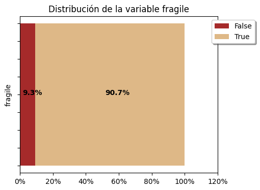

```python
# ======================================================
# 1) DISTRIBUCIÓN DEL TARGET (fragile)
# ======================================================

# ✅ Instanciamos el analizador
analisis_btc = Analisis_Predictivo(df_btc.drop(columns=["fragile_num"]), predecir=TARGET)

# 📊 Distribución de la variable objetivo
analisis_btc.distribucion_variable_predecir()
```

```python
# ======================================================
# 2) TOP FEATURES por correlación con el target (rápido)
# ======================================================

corr_target = (
    df_btc[feature_cols + ["fragile_num"]]
    .corr(numeric_only=True)["fragile_num"]
    .drop("fragile_num")
)

display(
    corr_target.abs().sort_values(ascending=False).to_frame("abs_corr")
)

top_vars = corr_target.abs().sort_values(ascending=False).head(10).index.tolist()
print("\n✅ Top 10 features (abs corr):", top_vars)
```

|  | abs_corr |
| --- | --- |
| early_mfe | 0.656853 |
| early_ret | 0.505788 |
| zspeed_mean | 0.342400 |
| hl_range_mean | 0.327902 |
| pos_zspeed_ratio | 0.259867 |
| zaccel_mean | 0.133893 |
| zspeed_slope | 0.131451 |
| zspeed_std | 0.026393 |
| zaccel_std | 0.008940 |

```
✅ Top 10 features (abs corr): ['early_mfe', 'early_ret', 'zspeed_mean', 'hl_range_mean', 'pos_zspeed_ratio', 'zaccel_mean', 'zspeed_slope', 'zspeed_std', 'zaccel_std']
```

```
📊 Variable numérica: early_mfe

📊 Variable numérica: early_ret

📊 Variable numérica: zspeed_mean

📊 Variable numérica: hl_range_mean

📊 Variable numérica: pos_zspeed_ratio

📊 Variable numérica: zaccel_mean

📊 Variable numérica: zspeed_slope

📊 Variable numérica: zspeed_std

📊 Variable numérica: zaccel_std
```

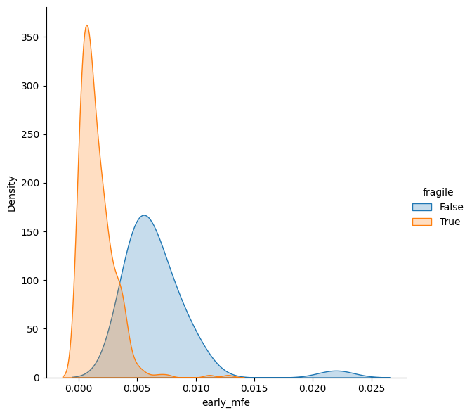

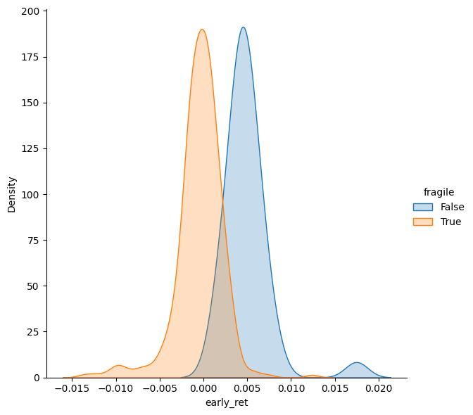

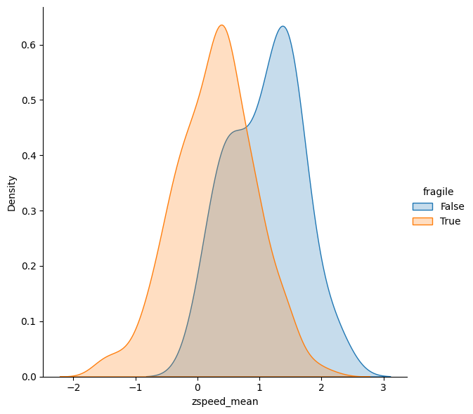

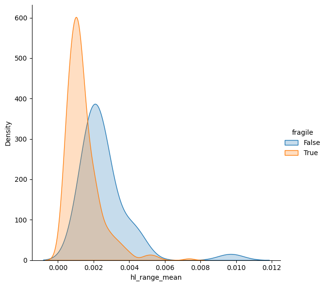

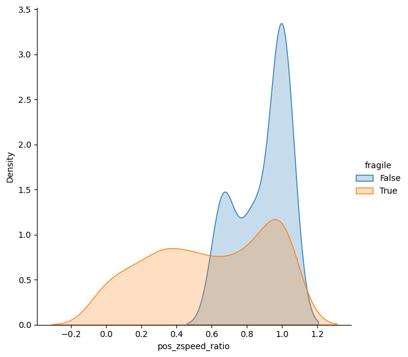

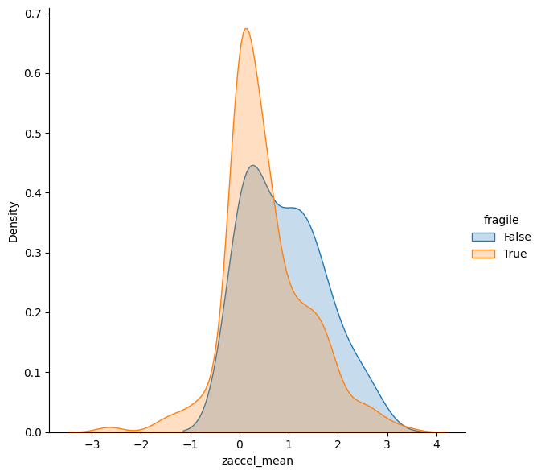

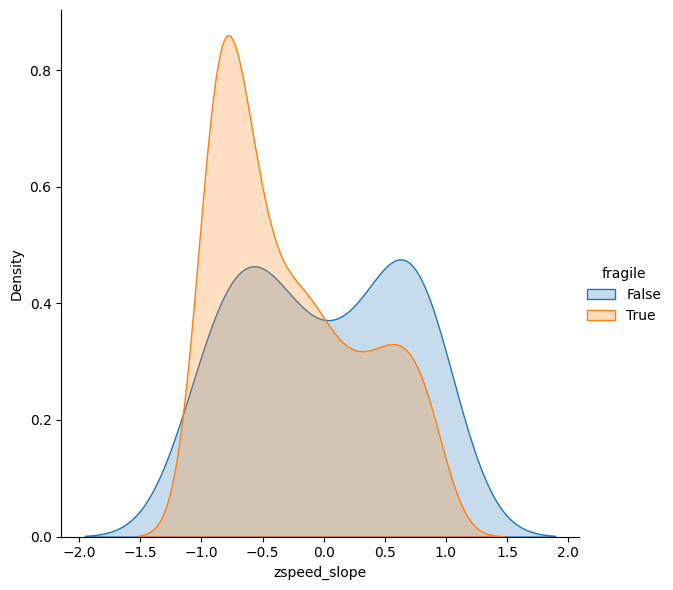

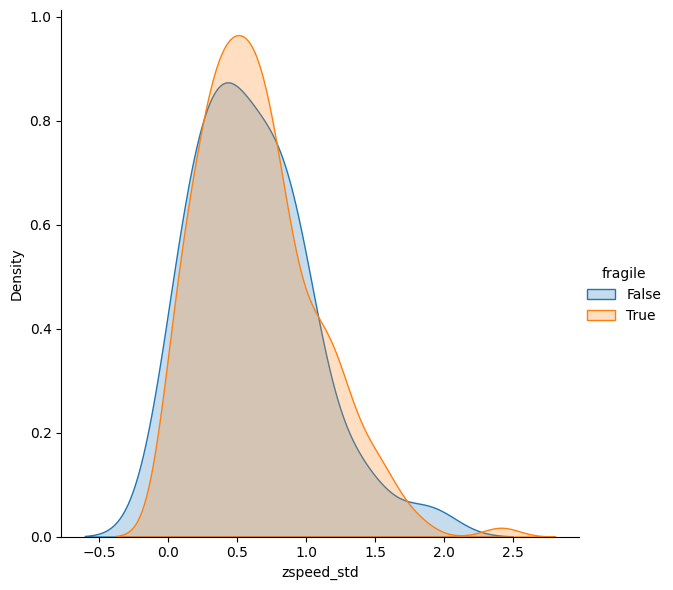

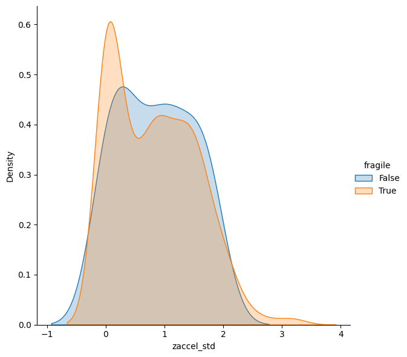

```python
# ======================================================
# 3) PODER PREDICTIVO — NUMÉRICAS (KDE por clase)
# ======================================================

for var in top_vars:
    print(f"\n📊 Variable numérica: {var}")
    analisis_btc.poder_predictivo_numerica(var)
```

```python
# ======================================================
# 4) PODER PREDICTIVO — CATEGÓRICAS (si existieran)
# ======================================================

columnas_categoricas = df_btc.select_dtypes(include=["object", "category"]).columns.tolist()
columnas_categoricas = [c for c in columnas_categoricas if c != TARGET]

if len(columnas_categoricas) == 0:
    print("✅ No hay variables categóricas en df_btc.")
else:
    for var in columnas_categoricas:
        print(f"\n📊 Variable categórica: {var}")
        analisis_btc.poder_predictivo_categorica(var)
```

```
✅ No hay variables categóricas en df_btc.
```

```python
# ======================================================
# 🧱 BLOQUE 2 — PREPARACIÓN DEL DATASET PARA MODELADO (ML)
#   - Selección de features (sin leakage)
#   - Target binario
#   - Detección de desbalance
#   - Definición de CV estratificada y scorer F1
#   - Pipelines base (con y sin SMOTE) listos para HPO
#   * Todo listo para BLOQUE 3/4 (HPO por modelo)
# ======================================================

import numpy as np
import pandas as pd

from sklearn.model_selection import StratifiedKFold
from sklearn.metrics import f1_score, make_scorer
from sklearn.preprocessing import StandardScaler
from sklearn.pipeline import Pipeline

# SMOTE solo se usará dentro de CV (pipeline)
from imblearn.over_sampling import SMOTE
from imblearn.pipeline import Pipeline as ImbPipeline

# ------------------------------------------------------
# 2.0) Asumimos df_ml ya creado en el BLOQUE 0
# ------------------------------------------------------
assert "fragile" in df_ml.columns, "df_ml no contiene la columna target 'fragile'."

TARGET = "fragile"

# ------------------------------------------------------
# 2.1) Definir columnas meta (NO usar como features)
# ------------------------------------------------------
meta_cols = [
    "trade_id",
    "entry_time","exit_time_baseline","exit_time_hybrid",
    "entry_price","exit_price_baseline","exit_price_hybrid",
    "exit_return_baseline","exit_return_hybrid",
    "giveback_x_mfe_baseline","giveback_x_mfe_hybrid",
    "delta_exit_return","delta_giveback_x_mfe",
    "used_deterioration","exited_early"
]

# ------------------------------------------------------
# 2.2) Construir lista de features candidatas (sin leakage)
# ------------------------------------------------------
feature_cols = [c for c in df_ml.columns if c not in meta_cols + [TARGET]]

# Mantener solo numéricas (lo esperado en tu df_ml)
feature_cols_num = df_ml[feature_cols].select_dtypes(include=[np.number]).columns.tolist()

# Si por alguna razón aparece una no-numérica en feature_cols, la excluimos
dropped_non_num = sorted(list(set(feature_cols) - set(feature_cols_num)))

print("✅ Target:", TARGET)
print("✅ Features candidatas:", len(feature_cols))
print("✅ Features numéricas (usadas):", len(feature_cols_num))
if dropped_non_num:
    print("⚠️ Features no-numéricas excluidas:", dropped_non_num)

# ------------------------------------------------------
# 2.3) Construir X (features) e y (target)
# ------------------------------------------------------
X = df_ml[feature_cols_num].copy()

# y como 0/1 (fragile=True -> 1)
y = df_ml[TARGET].astype(int).values

print("\n✅ X shape:", X.shape)
print("✅ y shape:", y.shape)

# ------------------------------------------------------
# 2.4) Chequeo de nulos/infs (sanity check)
# ------------------------------------------------------
n_nulls = int(X.isnull().sum().sum())
n_infs  = int(np.isinf(X.values).sum())

print("\n🔎 Sanity checks")
print(" - Nulls en X:", n_nulls)
print(" - Infs  en X:", n_infs)

# Si hay infs, reemplazamos por NaN y luego imputamos con mediana (rápido y robusto)
if n_infs > 0:
    X = X.replace([np.inf, -np.inf], np.nan)

# Si hay NaNs, imputación simple (mediana por columna)
if int(X.isnull().sum().sum()) > 0:
    X = X.fillna(X.median(numeric_only=True))

# ------------------------------------------------------
# 2.5) Distribución del target (desbalance)
# ------------------------------------------------------
counts = pd.Series(y).value_counts().sort_index()
pct = counts / counts.sum()

# 0 = no frágil, 1 = frágil
print("\n📊 Distribución del target (0=no frágil, 1=frágil)")
for k in counts.index:
    print(f" - Clase {k}: {counts[k]} ({pct[k]*100:.2f}%)")

minority_pct = float(pct.min())
print("\n✅ % clase minoritaria:", round(minority_pct*100, 2), "%")

# ------------------------------------------------------
# 2.6) CV estratificada + métrica objetivo
# ------------------------------------------------------
# Nota: no forzamos random_state (según tu preferencia)
# Si quisieras estabilidad para paper, se puede fijar luego.
cv = StratifiedKFold(n_splits=5, shuffle=True)

f1_macro = make_scorer(f1_score, average="macro")

print("\n✅ CV:", type(cv).__name__, "| n_splits=5 | shuffle=True")
print("✅ Scorer:", "F1 macro")

# ------------------------------------------------------
# 2.7) Pipelines base para HPO
# ------------------------------------------------------
# A) Pipeline estándar (sin SMOTE) — útil para árboles/boosting y Halving
pipe_std = Pipeline([
    ("scaler", StandardScaler()),
    ("model", None)  # placeholder
])

# B) Pipeline con SMOTE — útil para modelos sensibles al desbalance (KNN/SVM/MLP/LDA/QDA)
# Importante: SMOTE solo dentro de CV (aquí está bien)
pipe_smote = ImbPipeline([
    ("scaler", StandardScaler()),
    ("smote", SMOTE(k_neighbors=2)),
    ("model", None)  # placeholder
])

print("\n✅ Pipelines base listos:")
print(" - pipe_std  (StandardScaler + model)")
print(" - pipe_smote(StandardScaler + SMOTE + model)")

# ------------------------------------------------------
# 2.8) Salidas del bloque (listas para siguientes bloques)
# ------------------------------------------------------
ARTIFACTS_BLOCK2 = {
    "TARGET": TARGET,
    "feature_cols_num": feature_cols_num,
    "X": X,
    "y": y,
    "cv": cv,
    "scorer": f1_macro,
    "pipe_std": pipe_std,
    "pipe_smote": pipe_smote
}

print("\n✅ ARTIFACTS_BLOCK2 creado. Listo para Bloque 3/4 (HPO).")
```

```
✅ Target: fragile
✅ Features candidatas: 9
✅ Features numéricas (usadas): 9

✅ X shape: (398, 9)
✅ y shape: (398,)

🔎 Sanity checks
 - Nulls en X: 0
 - Infs  en X: 0

📊 Distribución del target (0=no frágil, 1=frágil)
 - Clase 0: 37 (9.30%)
 - Clase 1: 361 (90.70%)

✅ % clase minoritaria: 9.3 %

✅ CV: StratifiedKFold | n_splits=5 | shuffle=True
✅ Scorer: F1 macro

✅ Pipelines base listos:
 - pipe_std  (StandardScaler + model)
 - pipe_smote(StandardScaler + SMOTE + model)

✅ ARTIFACTS_BLOCK2 creado. Listo para Bloque 3/4 (HPO).
```

```
✅ df_eda: (398, 10)
✅ Features: ['early_ret', 'early_mfe', 'pos_zspeed_ratio', 'zspeed_mean', 'zspeed_std', 'zaccel_mean', 'zaccel_std', 'zspeed_slope', 'hl_range_mean']
```

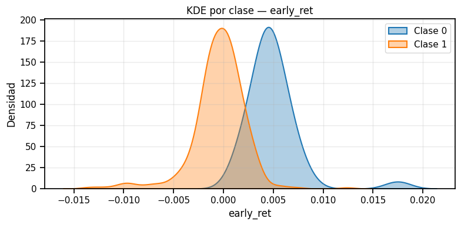

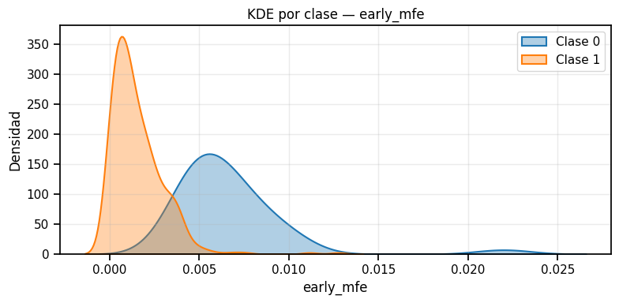

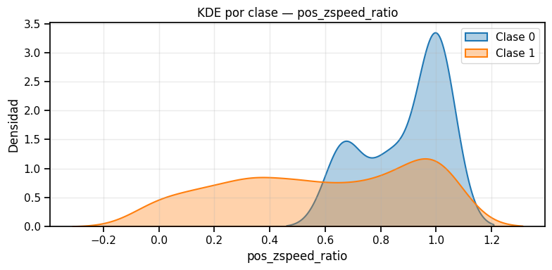

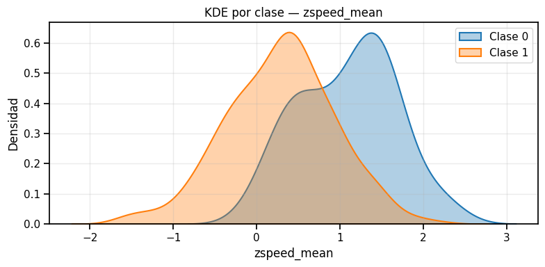

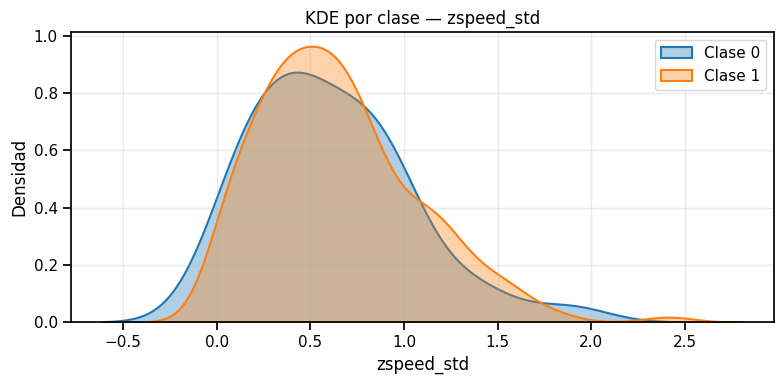

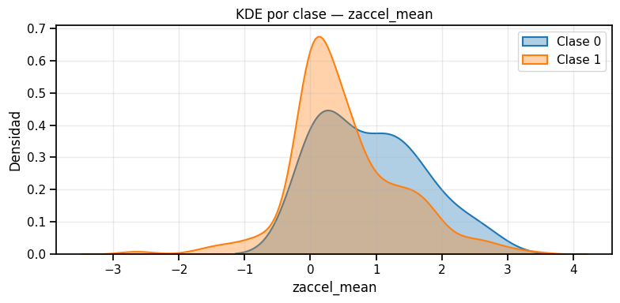

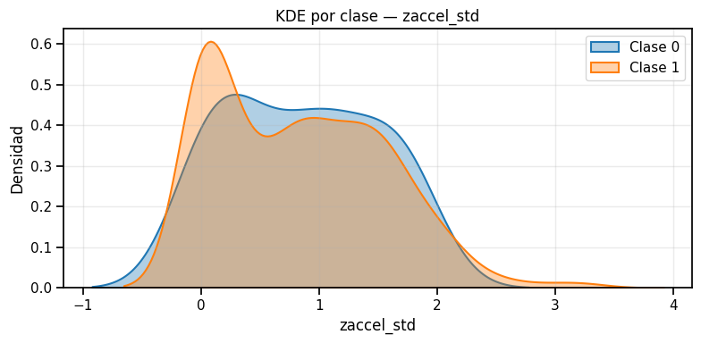

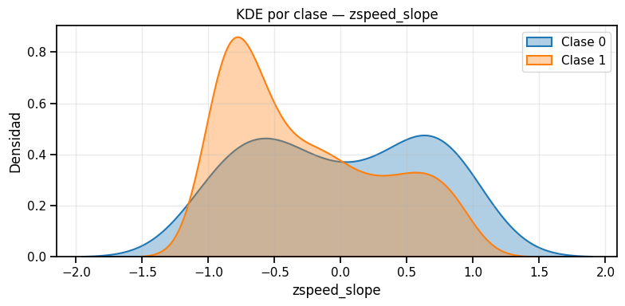

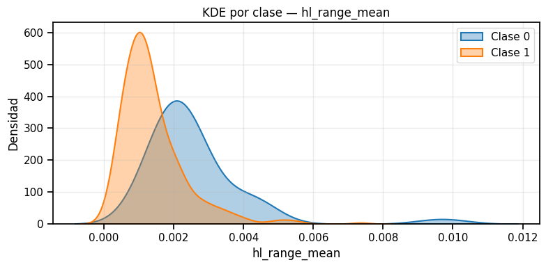

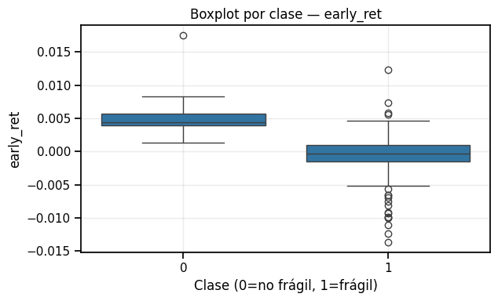

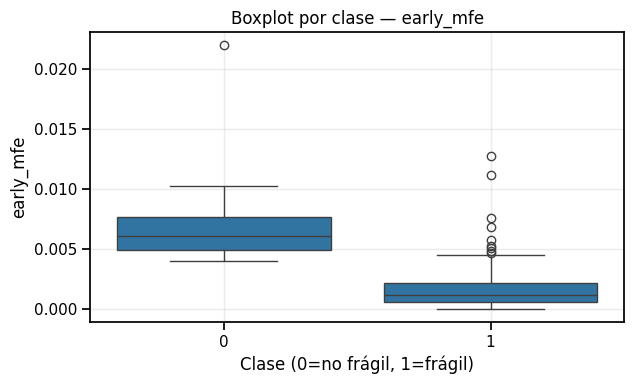

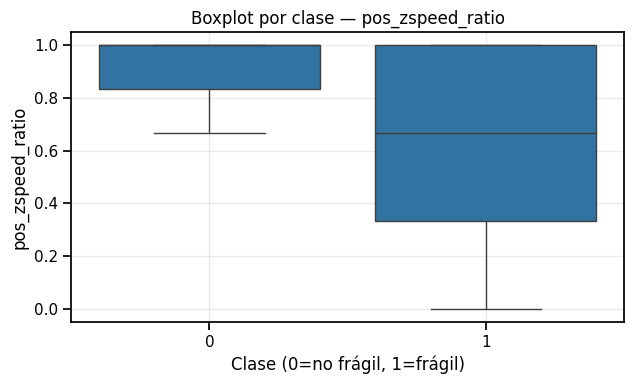

[6 more figures not shown]

```
🏁 Ranking univariado de separación (mayor = mejor):
```

|  | feature | auc_uni | std_mean_diff | mean_cls0 | mean_cls1 |
| --- | --- | --- | --- | --- | --- |
| 0 | early_mfe | 0.985 | -2.074 | 0.0067 | 0.0016 |
| 1 | early_ret | 0.970 | -2.010 | 0.0049 | -0.0005 |
| 2 | hl_range_mean | 0.841 | -0.962 | 0.0026 | 0.0014 |
| 3 | zspeed_mean | 0.821 | -1.317 | 1.0839 | 0.2797 |
| 4 | pos_zspeed_ratio | 0.756 | -1.159 | 0.8874 | 0.5877 |
| 5 | zaccel_mean | 0.632 | -0.476 | 0.9151 | 0.5267 |
| 6 | zspeed_slope | 0.620 | -0.432 | -0.0035 | -0.2712 |
| 7 | zspeed_std | 0.525 | 0.091 | 0.6108 | 0.6491 |
| 8 | zaccel_std | 0.520 | -0.032 | 0.8490 | 0.8274 |

```python
# ======================================================
# 🧱 BLOQUE 3A — PODER PREDICTIVO (UNIVARIADO) — NUMÉRICAS
#   - KDE por clase (fragile)
#   - Boxplot por clase (fragile)
#   - Ranking rápido por separación: |mean_diff| y AUC univariado (opcional)
#
# Requisitos:
#   - X, y, TARGET, feature_cols_num ya definidos en BLOQUE 2
#   - df_ml disponible
# ======================================================

import numpy as np
import pandas as pd
import matplotlib.pyplot as plt
import seaborn as sns

from sklearn.metrics import roc_auc_score

# ------------------------------------------------------
# 3A.0) Dataset de trabajo (features + target)
# ------------------------------------------------------
TARGET = "fragile"  # por claridad
df_eda = df_ml[feature_cols_num + [TARGET]].copy()

# Asegurar target 0/1 para plots consistentes
df_eda[TARGET] = df_eda[TARGET].astype(int)

print("✅ df_eda:", df_eda.shape)
print("✅ Features:", feature_cols_num)

# ------------------------------------------------------
# 3A.1) KDE por clase (uno por variable)
# ------------------------------------------------------
sns.set_context("notebook")

for var in feature_cols_num:
    plt.figure(figsize=(8, 4))

    # KDE para cada clase (0/1)
    for cls in sorted(df_eda[TARGET].unique()):
        data_cls = df_eda.loc[df_eda[TARGET] == cls, var].values
        if np.std(data_cls) == 0:
            # Si no hay variación, evitamos errores/plots raros
            plt.hist(data_cls, bins=10, alpha=0.5, label=f"Clase {cls} (sin var)")
        else:
            sns.kdeplot(
                data=data_cls,
                fill=True,
                common_norm=False,
                alpha=0.35,
                linewidth=1.5,
                label=f"Clase {cls}"
            )

    plt.title(f"KDE por clase — {var}")
    plt.xlabel(var)
    plt.ylabel("Densidad")
    plt.grid(alpha=0.25)
    plt.legend()
    plt.tight_layout()
    plt.show()

# ------------------------------------------------------
# 3A.2) Boxplot por clase (uno por variable)
# ------------------------------------------------------
for var in feature_cols_num:
    plt.figure(figsize=(6.5, 4))
    sns.boxplot(
        data=df_eda,
        x=TARGET,
        y=var
    )
    plt.title(f"Boxplot por clase — {var}")
    plt.xlabel("Clase (0=no frágil, 1=frágil)")
    plt.ylabel(var)
    plt.grid(alpha=0.25)
    plt.tight_layout()
    plt.show()

# ------------------------------------------------------
# 3A.3) Ranking rápido de separación (tabla)
#      - diferencia de medias estandarizada (Cohen-like)
#      - AUC univariado (si aplica)
# ------------------------------------------------------
rows = []
y01 = df_eda[TARGET].values

for var in feature_cols_num:
    x = df_eda[var].values
    x0 = x[y01 == 0]
    x1 = x[y01 == 1]

    # mean/std por clase
    m0, m1 = float(np.mean(x0)), float(np.mean(x1))
    s0, s1 = float(np.std(x0, ddof=1)), float(np.std(x1, ddof=1))

    # pooled std (evitar división por 0)
    pooled = np.sqrt((s0**2 + s1**2) / 2.0) if (s0 > 0 or s1 > 0) else np.nan
    std_mean_diff = (m1 - m0) / pooled if pooled and not np.isnan(pooled) and pooled > 0 else np.nan

    # AUC univariado (si hay variación)
    auc = np.nan
    if np.std(x) > 0:
        try:
            auc = float(roc_auc_score(y01, x))
            # Si AUC < 0.5, invertimos la interpretación (misma potencia)
            auc = max(auc, 1.0 - auc)
        except Exception:
            auc = np.nan

    rows.append({
        "feature": var,
        "mean_cls0": m0,
        "mean_cls1": m1,
        "std_mean_diff": std_mean_diff,  # magnitud de separación
        "auc_uni": auc                   # 0.5 = nada, 1.0 = separación perfecta
    })

df_sep = pd.DataFrame(rows)

# Ranking: primero AUC, luego |std_mean_diff|
df_sep["abs_std_mean_diff"] = df_sep["std_mean_diff"].abs()

df_sep = df_sep.sort_values(
    by=["auc_uni", "abs_std_mean_diff"],
    ascending=[False, False]
).reset_index(drop=True)

print("\n🏁 Ranking univariado de separación (mayor = mejor):")
display(
    df_sep[["feature","auc_uni","std_mean_diff","mean_cls0","mean_cls1"]]
    .style.format({
        "auc_uni":"{:.3f}",
        "std_mean_diff":"{:.3f}",
        "mean_cls0":"{:.4f}",
        "mean_cls1":"{:.4f}",
    })
)
```

### El régimen temprano del trade es altamente predecible utilizando únicamente información disponible en los primeros 30 minutos post‐entrada. Variables relacionadas con el avance máximo temprano (MFE), el retorno inicial y la persistencia del momentum explican de forma clara la diferencia entre trades frágiles y convexos, validando empíricamente el enfoque de clasificación temprana utilizado por el modelo híbrido.

```
✅ df_corr shape: (398, 9)
```

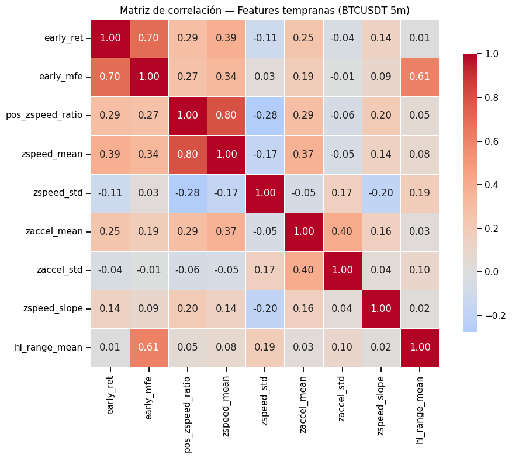

```
✅ No hay pares con |correlación| ≥ 0.85.

🎯 Correlación feature ↔ target (fragile):
```

|  | corr_fragile |
| --- | --- |
| early_mfe | -0.657 |
| early_ret | -0.506 |
| zspeed_mean | -0.342 |
| hl_range_mean | -0.328 |
| pos_zspeed_ratio | -0.260 |
| zaccel_mean | -0.134 |
| zspeed_slope | -0.131 |
| zspeed_std | 0.026 |
| zaccel_std | -0.009 |

```python
# ======================================================
# 🧱 BLOQUE 3B — CORRELACIÓN Y REDUNDANCIA ENTRE FEATURES (ROBUSTO)
# ======================================================

import seaborn as sns
import matplotlib.pyplot as plt

# ------------------------------------------------------
# 3B.0) Dataset solo con features numéricas
# ------------------------------------------------------
df_corr = df_ml[feature_cols_num].copy()

print("✅ df_corr shape:", df_corr.shape)

# ------------------------------------------------------
# 3B.1) Matriz de correlación (Pearson)
# ------------------------------------------------------
corr = df_corr.corr(method="pearson")

plt.figure(figsize=(10, 8))
sns.heatmap(
    corr,
    annot=True,
    fmt=".2f",
    cmap="coolwarm",
    center=0,
    square=True,
    linewidths=0.5,
    cbar_kws={"shrink": 0.8}
)
plt.title("Matriz de correlación — Features tempranas (BTCUSDT 5m)")
plt.tight_layout()
plt.show()

# ------------------------------------------------------
# 3B.2) Pares altamente correlacionados
# ------------------------------------------------------
THR = 0.85  # umbral alto (estricto)

pairs = []
cols = corr.columns.tolist()

for i in range(len(cols)):
    for j in range(i + 1, len(cols)):
        val = float(corr.iloc[i, j])
        if abs(val) >= THR:
            pairs.append((cols[i], cols[j], val))

if len(pairs) == 0:
    print(f"\n✅ No hay pares con |correlación| ≥ {THR}.")
    df_high_corr = pd.DataFrame(columns=["feature_1", "feature_2", "corr"])
else:
    df_high_corr = pd.DataFrame(pairs, columns=["feature_1", "feature_2", "corr"])
    df_high_corr["abs_corr"] = df_high_corr["corr"].abs()
    df_high_corr = df_high_corr.sort_values("abs_corr", ascending=False).drop(columns=["abs_corr"])

    print(f"\n🔍 Pares con |correlación| ≥ {THR}:")
    display(df_high_corr.style.format({"corr": "{:.3f}"}))

# ------------------------------------------------------
# 3B.3) Correlación respecto al target (fragile)
# ------------------------------------------------------
# Nota: TARGET en tu notebook es "fragile"
corr_target = (
    df_ml[feature_cols_num + [TARGET]]
    .corr(method="pearson")[TARGET]
    .drop(TARGET)
    .sort_values(key=lambda x: x.abs(), ascending=False)
)

print("\n🎯 Correlación feature ↔ target (fragile):")
display(
    corr_target.to_frame("corr_fragile")
    .style.format({"corr_fragile": "{:.3f}"})
)
```

#### La exploración univariada y de correlación confirma que el régimen frágil es altamente predecible con información de los primeros 30 minutos post‐entrada. Las variables de follow-through temprano (early_mfe y early_ret) concentran la mayor señal, mientras que no se observa colinealidad extrema entre predictores (|ρ|<0.85), lo cual permite conservar el conjunto completo de features para el entrenamiento multivariado.

# Empezamos HPO

```python
# ======================================================
# 📦 CONTENEDOR GLOBAL DE MEJORES MODELOS (BLOQUE 4)
# ======================================================
best_params = {}
```

## KNN

```python
# ======================================================
# 🔹 BLOQUE 4A — HPO KNN (Clasificación fragile) [CORREGIDO]
# Objetivo del fix:
# ✅ Mantener tus condiciones (sin random_state salvo cuando el método lo exige)
# ✅ Guardar SIEMPRE el ganador en best_params con la estructura estándar:
#    best_params["KNN"] = {"method": ..., "params": ..., "f1_cv": ...}
# ✅ Además guardar si el ganador usó SMOTE o no (para que Bloque 5 pueda replicarlo)
# ======================================================

import numpy as np
import pandas as pd
import multiprocessing
import warnings
warnings.filterwarnings("ignore")

from sklearn.model_selection import StratifiedKFold, GridSearchCV, RandomizedSearchCV
from sklearn.experimental import enable_halving_search_cv  # noqa
from sklearn.model_selection import HalvingRandomSearchCV

from skopt import BayesSearchCV
from skopt.space import Integer, Categorical
from scipy.stats import randint

from sklearn.pipeline import Pipeline
from sklearn.preprocessing import StandardScaler
from sklearn.neighbors import KNeighborsClassifier
from sklearn.metrics import f1_score, make_scorer

from imblearn.over_sampling import SMOTE
from imblearn.pipeline import Pipeline as ImbPipeline


# ======================================================
# ⚙️ CONFIGURACIÓN GENERAL
# ======================================================

n_jobs = multiprocessing.cpu_count()
f1_macro = make_scorer(f1_score, average="macro")

# CV REALISTA (default)
cv_real = StratifiedKFold(n_splits=5, shuffle=True)

# CV DETERMINÍSTICO (SOLO para Halving) — requerido por el método
cv_halving = StratifiedKFold(
    n_splits=5,
    shuffle=True,
    random_state=42  # ⚠️ requerido por Halving
)

print(f"✅ KNN HPO | cores={n_jobs} | scorer=F1-macro")


# ======================================================
# 🧩 PIPELINES BASE
# ======================================================

pipe_std = Pipeline([
    ("scaler", StandardScaler()),
    ("model", KNeighborsClassifier())
])

pipe_smote = ImbPipeline([
    ("scaler", StandardScaler()),
    ("smote", SMOTE()),
    ("model", KNeighborsClassifier())
])


# ======================================================
# 🔍 ESPACIOS DE BÚSQUEDA
# ======================================================

param_grid = {
    "model__n_neighbors": [3, 5, 7, 9, 11, 13, 15],
    "model__algorithm": ["ball_tree", "kd_tree", "brute"],
    "model__p": [1, 2, 3]
}

param_dist = {
    "model__n_neighbors": randint(3, 16),
    "model__algorithm": ["ball_tree", "kd_tree", "brute"],
    "model__p": randint(1, 4)
}

param_bayes = {
    "model__n_neighbors": Integer(3, 15),
    "model__algorithm": Categorical(["ball_tree", "kd_tree", "brute"]),
    "model__p": Integer(1, 3)
}


# ======================================================
# 🚀 FUNCIÓN HPO — KNN
# ======================================================

def hpo_knn(X, y):
    """
    Retorna un DataFrame con los métodos y su mejor score/params.
    Además marca si el ganador usó SMOTE o no (clave para Bloque 5).
    """
    resultados = []

    # -------------------------
    # 1) GridSearchCV (SMOTE)
    # -------------------------
    grid = GridSearchCV(
        pipe_smote,
        param_grid,
        scoring=f1_macro,
        cv=cv_real,
        n_jobs=n_jobs,
        refit=True,
        error_score=np.nan
    )
    grid.fit(X, y)
    resultados.append(("GridSearch", float(grid.best_score_), dict(grid.best_params_), True))  # True=SMOTE

    # -------------------------
    # 2) RandomizedSearchCV (SMOTE)
    # -------------------------
    rand = RandomizedSearchCV(
        pipe_smote,
        param_distributions=param_dist,
        n_iter=60,
        scoring=f1_macro,
        cv=cv_real,
        n_jobs=n_jobs,
        error_score=np.nan
    )
    rand.fit(X, y)
    resultados.append(("Randomized", float(rand.best_score_), dict(rand.best_params_), True))  # True=SMOTE

    # -------------------------
    # 3) HalvingRandomSearchCV (SIN SMOTE)
    # (CV determinístico requerido)
    # -------------------------
    if len(y) >= 300:
        halv = HalvingRandomSearchCV(
            pipe_std,                      # ⚠️ sin SMOTE
            param_distributions=param_dist,
            scoring=f1_macro,
            cv=cv_halving,                 # 👈 clave
            factor=3,
            n_jobs=n_jobs,
            random_state=42,               # ⚠️ obligatorio
            error_score=np.nan
        )
        halv.fit(X, y)
        resultados.append(("Halving", float(halv.best_score_), dict(halv.best_params_), False))  # False=NO SMOTE

    # -------------------------
    # 4) BayesSearchCV (SMOTE)
    # (requiere random_state)
    # -------------------------
    bayes = BayesSearchCV(
        pipe_smote,
        search_spaces=param_bayes,
        n_iter=40,
        scoring=f1_macro,
        cv=cv_real,
        n_jobs=n_jobs,
        random_state=42,                  # ⚠️ requerido por el método
        error_score=np.nan
    )
    bayes.fit(X, y)
    resultados.append(("BayesSearch", float(bayes.best_score_), dict(bayes.best_params_), True))  # True=SMOTE

    # -------------------------
    # Consolidar resultados
    # -------------------------
    df = (
        pd.DataFrame(resultados, columns=["Metodo", "F1_CV_Promedio", "Mejores_Parametros", "Usa_SMOTE"])
        .sort_values("F1_CV_Promedio", ascending=False)
        .reset_index(drop=True)
    )
    return df


# ======================================================
# 🏁 EJECUCIÓN — KNN
# ======================================================

print("\n🚀 Ejecutando HPO KNN...")
df_knn_results = hpo_knn(X, y)

pd.set_option("display.max_colwidth", None)
pd.set_option("display.max_columns", None)
pd.set_option("display.width", 200)

print("\n🏆 RESULTADOS — KNN (ordenado por F1 macro):")
display(df_knn_results)

best_knn = df_knn_results.iloc[0]

print("🏆 Mejor método KNN:")
print(best_knn["Metodo"])
print("F1:", round(float(best_knn["F1_CV_Promedio"]), 4))
print("Usa SMOTE:", bool(best_knn["Usa_SMOTE"]))


# ======================================================
# ✅ Guardar KNN ganador en best_params (estructura estándar)
# + guardamos si usa SMOTE (clave para Bloque 5)
# ======================================================

best_params["KNN"] = {
    "method": str(best_knn["Metodo"]),
    "params": dict(best_knn["Mejores_Parametros"]),
    "f1_cv": float(best_knn["F1_CV_Promedio"]),
    "use_smote": bool(best_knn["Usa_SMOTE"])
}

print("\n✅ KNN guardado en best_params:")
print(best_params["KNN"])
```

```
✅ KNN HPO | cores=56 | scorer=F1-macro

🚀 Ejecutando HPO KNN...

🏆 RESULTADOS — KNN (ordenado por F1 macro):
```

|  | Metodo | F1_CV_Promedio | Mejores_Parametros | Usa_SMOTE |
| --- | --- | --- | --- | --- |
| 0 | BayesSearch | 0.879083 | {'model__algorithm': 'ball_tree', 'model__n_neighbors': 3, 'model__p': 2} | True |
| 1 | GridSearch | 0.878628 | {'model__algorithm': 'brute', 'model__n_neighbors': 3, 'model__p': 1} | True |
| 2 | Randomized | 0.869283 | {'model__algorithm': 'brute', 'model__n_neighbors': 4, 'model__p': 1} | True |
| 3 | Halving | 0.847101 | {'model__algorithm': 'kd_tree', 'model__n_neighbors': 4, 'model__p': 1} | False |

```
🏆 Mejor método KNN:
BayesSearch
F1: 0.8791
Usa SMOTE: True

✅ KNN guardado en best_params:
{'method': 'BayesSearch', 'params': {'model__algorithm': 'ball_tree', 'model__n_neighbors': 3, 'model__p': 2}, 'f1_cv': 0.8790831142671169, 'use_smote': True}
```

## SVM

```python
# ======================================================
# 📦 BLOQUE 4B — SVM
# ======================================================

from sklearn.svm import SVC
from sklearn.model_selection import GridSearchCV, RandomizedSearchCV
from sklearn.experimental import enable_halving_search_cv  # noqa
from sklearn.model_selection import HalvingRandomSearchCV
from skopt import BayesSearchCV
from skopt.space import Real, Integer, Categorical
from scipy.stats import loguniform



def hpo_svm(X, y):

    resultados = []

    pipe_std = Pipeline([
        ("scaler", StandardScaler()),
        ("model", SVC())
    ])

    # ==================================================
    # 1️⃣ SVM LINEAR
    # ==================================================
    param_linear = {
        "model__kernel": ["linear"],
        "model__C": loguniform(1e-3, 1e2)
    }

    rand_linear = RandomizedSearchCV(
        pipe_std,
        param_distributions=param_linear,
        n_iter=40,
        scoring=f1_macro,
        cv=cv,
        n_jobs=-1,
        random_state=42,   # requerido
        error_score=np.nan
    )
    rand_linear.fit(X, y)
    resultados.append(("Randomized-linear", rand_linear.best_score_, rand_linear.best_params_))

    bayes_linear = BayesSearchCV(
        pipe_std,
        search_spaces={
            "model__kernel": Categorical(["linear"]),
            "model__C": Real(1e-3, 1e2, prior="log-uniform")
        },
        n_iter=30,
        scoring=f1_macro,
        cv=cv,
        n_jobs=-1,
        random_state=42,
        error_score=np.nan
    )
    bayes_linear.fit(X, y)
    resultados.append(("Bayes-linear", bayes_linear.best_score_, bayes_linear.best_params_))

    # ==================================================
    # 2️⃣ SVM RBF
    # ==================================================
    param_rbf = {
        "model__kernel": ["rbf"],
        "model__C": loguniform(1e-3, 1e2),
        "model__gamma": loguniform(1e-4, 1e-1)
    }

    rand_rbf = RandomizedSearchCV(
        pipe_std,
        param_distributions=param_rbf,
        n_iter=50,
        scoring=f1_macro,
        cv=cv,
        n_jobs=-1,
        random_state=42,
        error_score=np.nan
    )
    rand_rbf.fit(X, y)
    resultados.append(("Randomized-rbf", rand_rbf.best_score_, rand_rbf.best_params_))

    bayes_rbf = BayesSearchCV(
        pipe_std,
        search_spaces={
            "model__kernel": Categorical(["rbf"]),
            "model__C": Real(1e-3, 1e2, prior="log-uniform"),
            "model__gamma": Real(1e-4, 1e-1, prior="log-uniform")
        },
        n_iter=40,
        scoring=f1_macro,
        cv=cv,
        n_jobs=-1,
        random_state=42,
        error_score=np.nan
    )
    bayes_rbf.fit(X, y)
    resultados.append(("Bayes-rbf", bayes_rbf.best_score_, bayes_rbf.best_params_))

    # ==================================================
    # 3️⃣ SVM POLY
    # ==================================================
    param_poly = {
        "model__kernel": ["poly"],
        "model__C": loguniform(1e-3, 1e2),
        "model__gamma": loguniform(1e-4, 1e-1),
        "model__degree": randint(2, 5)
    }

    rand_poly = RandomizedSearchCV(
        pipe_std,
        param_distributions=param_poly,
        n_iter=40,
        scoring=f1_macro,
        cv=cv,
        n_jobs=-1,
        random_state=42,
        error_score=np.nan
    )
    rand_poly.fit(X, y)
    resultados.append(("Randomized-poly", rand_poly.best_score_, rand_poly.best_params_))

    bayes_poly = BayesSearchCV(
        pipe_std,
        search_spaces={
            "model__kernel": Categorical(["poly"]),
            "model__C": Real(1e-3, 1e2, prior="log-uniform"),
            "model__gamma": Real(1e-4, 1e-1, prior="log-uniform"),
            "model__degree": Integer(2, 4)
        },
        n_iter=30,
        scoring=f1_macro,
        cv=cv,
        n_jobs=-1,
        random_state=42,
        error_score=np.nan
    )
    bayes_poly.fit(X, y)
    resultados.append(("Bayes-poly", bayes_poly.best_score_, bayes_poly.best_params_))

    # ==================================================
    # 📊 Consolidación
    # ==================================================
    df = (
        pd.DataFrame(resultados, columns=["Metodo", "F1_CV_Promedio", "Mejores_Parametros"])
        .sort_values("F1_CV_Promedio", ascending=False)
        .reset_index(drop=True)
    )

    return df

print("\n🚀 Ejecutando HPO SVM (corregido)...")
df_svm_results = hpo_svm(X, y)

pd.set_option("display.max_colwidth", None)
display(df_svm_results)

best_svm = df_svm_results.iloc[0]

best_params["SVM"] = {
    "method": best_svm["Metodo"],
    "params": best_svm["Mejores_Parametros"],
    "f1_cv": best_svm["F1_CV_Promedio"]
}

print("\n🏆 Mejor SVM:")
print(best_svm["Metodo"])
print("F1:", round(best_svm["F1_CV_Promedio"], 4))
```

```
🚀 Ejecutando HPO SVM (corregido)...
```

|  | Metodo | F1_CV_Promedio | Mejores_Parametros |
| --- | --- | --- | --- |
| 0 | Bayes-rbf | 0.930272 | {'model__C': 58.930839732905675, 'model__gamma': 0.025781713975266324, 'model__kernel': 'rbf'} |
| 1 | Bayes-linear | 0.927797 | {'model__C': 9.948719998234102, 'model__kernel': 'linear'} |
| 2 | Randomized-rbf | 0.912255 | {'model__C': 70.45683638454501, 'model__gamma': 0.021154290797261225, 'model__kernel': 'rbf'} |
| 3 | Bayes-poly | 0.911152 | {'model__C': 100.0, 'model__degree': 3, 'model__gamma': 0.04886753153613255, 'model__kernel': 'poly'} |
| 4 | Randomized-linear | 0.904280 | {'model__C': 4.5705630998014515, 'model__kernel': 'linear'} |
| 5 | Randomized-poly | 0.900996 | {'model__C': 42.982762978218666, 'model__degree': 4, 'model__gamma': 0.058293845429947415, 'model__kernel': 'poly'} |

```
🏆 Mejor SVM:
Bayes-rbf
F1: 0.9303
```

# Arboles y Consenso

```python
# ======================================================
# 📦 BLOQUE 4C — ÁRBOLES Y ENSAMBLES [ANTI-SOBRESCRITURA]
# ======================================================

import numpy as np
import pandas as pd

from sklearn.tree import DecisionTreeClassifier
from sklearn.ensemble import (
    RandomForestClassifier,
    GradientBoostingClassifier,
    AdaBoostClassifier
)

from sklearn.model_selection import StratifiedKFold, GridSearchCV, RandomizedSearchCV
from sklearn.metrics import f1_score, make_scorer
from scipy.stats import randint, uniform

# ======================================================
# ⚙️ CONFIGURACIÓN GENERAL
# ======================================================

f1_macro = make_scorer(f1_score, average="macro")
cv = StratifiedKFold(n_splits=5, shuffle=True)  # ✅ sin random_state

cores = -1
print("✅ Árboles / Ensambles | scorer=F1-macro | CV estratificada")

# ======================================================
# ✅ SEGURIDAD: best_params DEBE existir y ser dict
# (evita que se cree otro dict "vacío" por accidente)
# ======================================================

assert "best_params" in globals(), (
    "❌ best_params NO existe. Debes inicializar best_params = {} una sola vez "
    "ANTES del primer HPO (p.ej., antes del Bloque 4A)."
)
assert isinstance(best_params, dict), "❌ best_params existe, pero NO es un dict."

# Guardamos qué modelos se agregan en este bloque (para resumen limpio de 4C)
models_4c = ["DecisionTree", "RandomForest", "GradientBoosting", "AdaBoost"]

# ======================================================
# 🧩 FUNCIÓN GENERAL DE HPO
# ======================================================

def hpo_model(nombre, model, param_grid, param_dist, X, y):
    resultados = []

    # -------------------------
    # Grid Search
    # -------------------------
    grid = GridSearchCV(
        model,
        param_grid=param_grid,
        scoring=f1_macro,
        cv=cv,
        n_jobs=cores,
        error_score=np.nan
    )
    grid.fit(X, y)
    resultados.append(("GridSearch", float(grid.best_score_), dict(grid.best_params_)))

    # -------------------------
    # Randomized Search
    # -------------------------
    rand = RandomizedSearchCV(
        model,
        param_distributions=param_dist,
        n_iter=40,
        scoring=f1_macro,
        cv=cv,
        n_jobs=cores,
        error_score=np.nan
    )
    rand.fit(X, y)
    resultados.append(("Randomized", float(rand.best_score_), dict(rand.best_params_)))

    # -------------------------
    # Consolidar
    # -------------------------
    df = (
        pd.DataFrame(resultados, columns=["Metodo", "F1_CV_Promedio", "Mejores_Parametros"])
        .sort_values("F1_CV_Promedio", ascending=False)
        .reset_index(drop=True)
    )

    # Guardar mejor modelo (⚠️ NO redefine best_params; solo asigna una key)
    best = df.iloc[0]
    best_params[nombre] = {
        "method": best["Metodo"],
        "params": best["Mejores_Parametros"],
        "f1_cv": best["F1_CV_Promedio"]
    }

    print(f"\n🏆 Mejor {nombre}: {best['Metodo']} | F1={best['F1_CV_Promedio']:.4f}")
    return df


# ======================================================
# 🌳 1️⃣ DECISION TREE
# ======================================================

print("\n🚀 HPO — Decision Tree")

dt = DecisionTreeClassifier()

dt_grid = {
    "max_depth": [None, 3, 5, 7, 10],
    "min_samples_split": [2, 5, 10],
    "min_samples_leaf": [1, 5, 10]
}

dt_dist = {
    "max_depth": [None, 3, 5, 7, 10, 15],
    "min_samples_split": randint(2, 15),
    "min_samples_leaf": randint(1, 15)
}

df_dt = hpo_model("DecisionTree", dt, dt_grid, dt_dist, X, y)
display(df_dt)


# ======================================================
# 🌲 2️⃣ RANDOM FOREST
# ======================================================

print("\n🚀 HPO — Random Forest")

rf = RandomForestClassifier(
    n_estimators=300,
    n_jobs=cores
)

rf_grid = {
    "max_depth": [None, 5, 10, 20],
    "min_samples_split": [2, 5, 10],
    "min_samples_leaf": [1, 5, 10]
}

rf_dist = {
    "max_depth": [None, 5, 10, 20, 30],
    "min_samples_split": randint(2, 20),
    "min_samples_leaf": randint(1, 20)
}

df_rf = hpo_model("RandomForest", rf, rf_grid, rf_dist, X, y)
display(df_rf)


# ======================================================
# ⚡ 3️⃣ GRADIENT BOOSTING
# ======================================================

print("\n🚀 HPO — Gradient Boosting")

gb = GradientBoostingClassifier()

gb_grid = {
    "n_estimators": [100, 200],
    "learning_rate": [0.05, 0.1],
    "max_depth": [2, 3]
}

gb_dist = {
    "n_estimators": randint(80, 250),
    "learning_rate": uniform(0.03, 0.15),
    "max_depth": randint(2, 5)
}

df_gb = hpo_model("GradientBoosting", gb, gb_grid, gb_dist, X, y)
display(df_gb)


# ======================================================
# 🔥 4️⃣ ADABOOST
# ======================================================

print("\n🚀 HPO — AdaBoost")

ada = AdaBoostClassifier()

ada_grid = {
    "n_estimators": [50, 100, 200],
    "learning_rate": [0.05, 0.1, 0.5]
}

ada_dist = {
    "n_estimators": randint(50, 300),
    "learning_rate": uniform(0.03, 0.6)
}

df_ada = hpo_model("AdaBoost", ada, ada_grid, ada_dist, X, y)
display(df_ada)


# ======================================================
# 📊 RESUMEN BLOQUE 4C (solo lo de este bloque)
# ======================================================

rows = []
for m in models_4c:
    if m in best_params:
        rows.append({
            "Modelo": m,
            "Metodo": best_params[m]["method"],
            "F1_CV_Promedio": float(best_params[m]["f1_cv"]),
            "Mejores_Parametros": best_params[m]["params"]
        })

df_summary_4c = (
    pd.DataFrame(rows)
    .sort_values("F1_CV_Promedio", ascending=False)
    .reset_index(drop=True)
)

print("\n📊 RESUMEN — BLOQUE 4C (ÁRBOLES Y ENSAMBLES)")
display(df_summary_4c)
```

```
✅ Árboles / Ensambles | scorer=F1-macro | CV estratificada

🚀 HPO — Decision Tree

🏆 Mejor DecisionTree: Randomized | F1=0.9760
```

|  | Metodo | F1_CV_Promedio | Mejores_Parametros |
| --- | --- | --- | --- |
| 0 | Randomized | 0.975962 | {'max_depth': None, 'min_samples_leaf': 3, 'min_samples_split': 8} |
| 1 | GridSearch | 0.959895 | {'max_depth': 5, 'min_samples_leaf': 1, 'min_samples_split': 2} |

```
🚀 HPO — Random Forest

🏆 Mejor RandomForest: GridSearch | F1=0.9633
```

|  | Metodo | F1_CV_Promedio | Mejores_Parametros |
| --- | --- | --- | --- |
| 0 | GridSearch | 0.963330 | {'max_depth': None, 'min_samples_leaf': 1, 'min_samples_split': 2} |
| 1 | Randomized | 0.950075 | {'max_depth': 30, 'min_samples_leaf': 1, 'min_samples_split': 5} |

```
🚀 HPO — Gradient Boosting

🏆 Mejor GradientBoosting: GridSearch | F1=0.9853
```

|  | Metodo | F1_CV_Promedio | Mejores_Parametros |
| --- | --- | --- | --- |
| 0 | GridSearch | 0.985287 | {'learning_rate': 0.05, 'max_depth': 2, 'n_estimators': 100} |
| 1 | Randomized | 0.974626 | {'learning_rate': 0.05442927216438581, 'max_depth': 2, 'n_estimators': 87} |

```
🚀 HPO — AdaBoost

🏆 Mejor AdaBoost: GridSearch | F1=0.9820
```

|  | Metodo | F1_CV_Promedio | Mejores_Parametros |
| --- | --- | --- | --- |
| 0 | GridSearch | 0.981982 | {'learning_rate': 0.5, 'n_estimators': 100} |
| 1 | Randomized | 0.974882 | {'learning_rate': 0.22456446316529896, 'n_estimators': 118} |

```
📊 RESUMEN — BLOQUE 4C (ÁRBOLES Y ENSAMBLES)
```

|  | Modelo | Metodo | F1_CV_Promedio | Mejores_Parametros |
| --- | --- | --- | --- | --- |
| 0 | GradientBoosting | GridSearch | 0.985287 | {'learning_rate': 0.05, 'max_depth': 2, 'n_estimators': 100} |
| 1 | AdaBoost | GridSearch | 0.981982 | {'learning_rate': 0.5, 'n_estimators': 100} |
| 2 | DecisionTree | Randomized | 0.975962 | {'max_depth': None, 'min_samples_leaf': 3, 'min_samples_split': 8} |
| 3 | RandomForest | GridSearch | 0.963330 | {'max_depth': None, 'min_samples_leaf': 1, 'min_samples_split': 2} |

```python
# ======================================================
# 📦 BLOQUE 4D — XGBoost (HPO) [REVISADO Y BLINDADO]
# - Scorer: F1 macro
# - CV base: cv (shuffle=True, sin random_state)
# - CV Halving: cv_halving con random_state fijo (requisito técnico)
# - Paralelización: n_jobs=-1 en los searchers
# - Evita nested parallelism: XGBClassifier(n_jobs=1)
# - Sin verbose: verbosity=0
# - Sin random_state salvo cuando el método lo exige
# - NO sobreescribe best_params
# ======================================================

import numpy as np
import pandas as pd

from xgboost import XGBClassifier

from sklearn.model_selection import GridSearchCV, RandomizedSearchCV, StratifiedKFold
from sklearn.experimental import enable_halving_search_cv  # noqa
from sklearn.model_selection import HalvingRandomSearchCV

from skopt import BayesSearchCV
from skopt.space import Real, Integer

from scipy.stats import randint, uniform, loguniform


def hpo_xgboost(X, y, cv, scorer, cores=-1):
    print(f"✅ XGBoost HPO | cores(search)={cores} | scorer=F1-macro")

    resultados = []

    # -------------------------
    # Modelo base (sin paralelismo interno para evitar nested parallelism)
    # -------------------------
    xgb_base = XGBClassifier(
        objective="binary:logistic",
        eval_metric="logloss",
        tree_method="hist",
        n_jobs=1,          # ✅ evita doble paralelización (CV ya va en paralelo)
        verbosity=0        # ✅ sin verbose
    )

    # -------------------------
    # CV especial SOLO para Halving (requisito técnico)
    # -------------------------
    # Tomamos n_splits del cv si existe, si no asumimos 5
    n_splits = getattr(cv, "n_splits", None) or 5
    cv_halving = StratifiedKFold(n_splits=n_splits, shuffle=True, random_state=42)  # ✅ requerido

    # ==================================================
    # 1) GRID
    # ==================================================
    param_grid = {
        "n_estimators": [100, 200, 300],
        "max_depth": [2, 3, 4, 5],
        "learning_rate": [0.03, 0.05, 0.10, 0.20],
        "subsample": [0.7, 0.9, 1.0],
        "colsample_bytree": [0.7, 0.9, 1.0],
        "min_child_weight": [1, 3, 5],
        "reg_lambda": [0.0, 1.0, 5.0]
    }

    grid = GridSearchCV(
        xgb_base,
        param_grid=param_grid,
        scoring=scorer,
        cv=cv,
        n_jobs=cores,      # ✅ paralelización en el searcher
        refit=True,
        error_score=np.nan
    )
    grid.fit(X, y)
    resultados.append(("GridSearch", float(grid.best_score_), dict(grid.best_params_)))

    # ==================================================
    # 2) RANDOMIZED (requiere random_state)
    # ==================================================
    param_dist = {
        "n_estimators": randint(80, 450),
        "max_depth": randint(2, 7),
        "learning_rate": loguniform(0.01, 0.30),
        "subsample": uniform(0.6, 0.4),
        "colsample_bytree": uniform(0.6, 0.4),
        "min_child_weight": randint(1, 10),
        "gamma": uniform(0.0, 0.8),
        "reg_alpha": loguniform(1e-6, 1.0),
        "reg_lambda": loguniform(1e-3, 10.0),
    }

    rand = RandomizedSearchCV(
        xgb_base,
        param_distributions=param_dist,
        n_iter=70,
        scoring=scorer,
        cv=cv,
        n_jobs=cores,
        random_state=42,   # ✅ requerido
        refit=True,
        error_score=np.nan
    )
    rand.fit(X, y)
    resultados.append(("Randomized", float(rand.best_score_), dict(rand.best_params_)))

    # ==================================================
    # 3) HALVING (usa cv_halving determinístico)
    # ==================================================
    halving = HalvingRandomSearchCV(
        xgb_base,
        param_distributions={
            "max_depth": randint(2, 7),
            "learning_rate": loguniform(0.01, 0.30),
            "subsample": uniform(0.6, 0.4),
            "colsample_bytree": uniform(0.6, 0.4),
            "min_child_weight": randint(1, 10),
            "gamma": uniform(0.0, 0.8),
            "reg_alpha": loguniform(1e-6, 1.0),
            "reg_lambda": loguniform(1e-3, 10.0),
        },
        scoring=scorer,
        cv=cv_halving,          # ✅ clave
        factor=3,
        resource="n_estimators",
        max_resources=450,
        min_resources=60,
        random_state=42,        # ✅ requerido
        n_jobs=cores,
        refit=True,
        error_score=np.nan
    )
    halving.fit(X, y)
    resultados.append(("Halving", float(halving.best_score_), dict(halving.best_params_)))

    # ==================================================
    # 4) BAYES (requiere random_state)
    # ==================================================
    bayes = BayesSearchCV(
        xgb_base,
        search_spaces={
            "n_estimators": Integer(80, 450),
            "max_depth": Integer(2, 6),
            "learning_rate": Real(0.01, 0.30, prior="log-uniform"),
            "subsample": Real(0.6, 1.0),
            "colsample_bytree": Real(0.6, 1.0),
            "min_child_weight": Integer(1, 10),
            "gamma": Real(0.0, 0.8),
            "reg_alpha": Real(1e-6, 1.0, prior="log-uniform"),
            "reg_lambda": Real(1e-3, 10.0, prior="log-uniform"),
        },
        n_iter=55,
        scoring=scorer,
        cv=cv,
        n_jobs=cores,
        random_state=42,   # ✅ requerido
        refit=True,
        error_score=np.nan
    )
    bayes.fit(X, y)
    resultados.append(("BayesSearch", float(bayes.best_score_), dict(bayes.best_params_)))

    # ==================================================
    # 📊 Consolidación
    # ==================================================
    df = (
        pd.DataFrame(resultados, columns=["Metodo", "F1_CV_Promedio", "Mejores_Parametros"])
        .sort_values("F1_CV_Promedio", ascending=False)
        .reset_index(drop=True)
    )

    pd.set_option("display.max_colwidth", None)
    pd.set_option("display.max_columns", None)
    pd.set_option("display.width", 200)

    return df


# ======================================================
# 🚀 EJECUCIÓN — XGBoost
# ======================================================
print("\n🚀 Ejecutando HPO XGBoost...")
df_xgb_results = hpo_xgboost(X, y, cv=cv, scorer=f1_macro, cores=-1)
display(df_xgb_results)

# ======================================================
# 🏆 Guardar ganador (sin sobrescribir best_params)
# ======================================================
if "best_params" not in globals():
    raise NameError("❌ best_params no existe. Inicialízalo UNA vez antes del Bloque 4A: best_params = {}")

best_xgb = df_xgb_results.iloc[0]
best_params["XGBoost"] = {
    "method": best_xgb["Metodo"],
    "params": dict(best_xgb["Mejores_Parametros"]),
    "f1_cv": float(best_xgb["F1_CV_Promedio"])
}

print("\n🏆 Mejor XGBoost:")
print(best_xgb["Metodo"])
print("F1:", round(float(best_xgb["F1_CV_Promedio"]), 4))
print("✅ best_params['XGBoost'] actualizado.")
```

```
🚀 Ejecutando HPO XGBoost...
✅ XGBoost HPO | cores(search)=-1 | scorer=F1-macro
```

|  | Metodo | F1_CV_Promedio | Mejores_Parametros |
| --- | --- | --- | --- |
| 0 | BayesSearch | 0.984271 | {'colsample_bytree': 0.8977930248513316, 'gamma': 0.22243763593068655, 'learning_rate': 0.2999999999028435, 'max_depth': 2, 'min_child_weight': 1, 'n_estimators': 386, 'reg_alpha': 3.7739035030447954e… |
| 1 | GridSearch | 0.984262 | {'colsample_bytree': 0.7, 'learning_rate': 0.03, 'max_depth': 2, 'min_child_weight': 1, 'n_estimators': 100, 'reg_lambda': 0.0, 'subsample': 0.9} |
| 2 | Randomized | 0.976896 | {'colsample_bytree': 0.6056319290860338, 'gamma': 0.15907392327104414, 'learning_rate': 0.11239275523180359, 'max_depth': 4, 'min_child_weight': 1, 'n_estimators': 340, 'reg_alpha': 0.3612478500429091… |
| 3 | Halving | 0.946340 | {'colsample_bytree': 0.6964101864104046, 'gamma': 0.5466108150603666, 'learning_rate': 0.07962309016748462, 'max_depth': 4, 'min_child_weight': 1, 'reg_alpha': 3.5700959600309506e-05, 'reg_lambda': 0.… |

```
🏆 Mejor XGBoost:
BayesSearch
F1: 0.9843
✅ best_params['XGBoost'] actualizado.
```

# MLP Classifier Sklearn

```python
# ======================================================
# 📦 BLOQUE 4E — MLPClassifier (sklearn) [FINAL]
# ======================================================

from sklearn.neural_network import MLPClassifier
from sklearn.model_selection import GridSearchCV, RandomizedSearchCV
from scipy.stats import loguniform
from imblearn.over_sampling import SMOTE
from imblearn.pipeline import Pipeline as ImbPipeline

def hpo_mlp(X, y):

    resultados = []

    # ---------------------------------------------
    # Pipeline base (StandardScaler + SMOTE + MLP)
    # ---------------------------------------------
    pipe_smote = ImbPipeline([
        ("scaler", StandardScaler()),
        ("smote", SMOTE()),
        ("model", MLPClassifier(
            max_iter=1000,
            early_stopping=True
        ))
    ])

    # ---------------------------------------------
    # Espacios de búsqueda
    # ---------------------------------------------
    param_grid = {
        "model__hidden_layer_sizes": [(32,), (64,), (32,16), (64,32)],
        "model__activation": ["relu", "tanh"],
        "model__alpha": [1e-4, 1e-3, 1e-2],
        "model__learning_rate_init": [1e-3, 1e-2]
    }

    param_dist = {
        "model__hidden_layer_sizes": [(32,), (64,), (32,16), (64,32), (64,32,16)],
        "model__activation": ["relu", "tanh"],
        "model__alpha": loguniform(1e-5, 1e-2),
        "model__learning_rate_init": loguniform(1e-4, 1e-2)
    }

    # ---------------------------------------------
    # 1️⃣ GridSearch
    # ---------------------------------------------
    grid = GridSearchCV(
        pipe_smote,
        param_grid,
        scoring=f1_macro,
        cv=cv,
        n_jobs=-1,
        error_score=np.nan
    )
    grid.fit(X, y)
    resultados.append(("GridSearch", float(grid.best_score_), dict(grid.best_params_)))

    # ---------------------------------------------
    # 2️⃣ RandomizedSearch (requiere random_state)
    # ---------------------------------------------
    rand = RandomizedSearchCV(
        pipe_smote,
        param_distributions=param_dist,
        n_iter=40,
        scoring=f1_macro,
        cv=cv,
        n_jobs=-1,
        random_state=42,   # requerido por el método
        error_score=np.nan
    )
    rand.fit(X, y)
    resultados.append(("Randomized", float(rand.best_score_), dict(rand.best_params_)))

    # ---------------------------------------------
    # Consolidar resultados
    # ---------------------------------------------
    df = (
        pd.DataFrame(resultados, columns=["Metodo", "F1_CV_Promedio", "Mejores_Parametros"])
        .sort_values("F1_CV_Promedio", ascending=False)
        .reset_index(drop=True)
    )

    return df


# ======================================================
# 🚀 EJECUCIÓN — MLPClassifier
# ======================================================

print("\n🚀 Ejecutando HPO MLPClassifier (Grid + Random, con SMOTE)...")
df_mlp_results = hpo_mlp(X, y)

pd.set_option("display.max_colwidth", None)
display(df_mlp_results)

# ======================================================
# 🏆 Guardar ganador (sin sobrescribir best_params)
# ======================================================
if "best_params" not in globals():
    raise NameError("❌ best_params no existe. Inicialízalo UNA vez antes del Bloque 4A: best_params = {}")

best_mlp = df_mlp_results.iloc[0]

best_params["MLPClassifier"] = {
    "method": best_mlp["Metodo"],
    "params": dict(best_mlp["Mejores_Parametros"]),
    "f1_cv": float(best_mlp["F1_CV_Promedio"]),
    "use_smote": True   # ✅ este bloque siempre usó SMOTE
}

print("\n🏆 Mejor MLPClassifier:")
print(best_mlp["Metodo"])
print("F1:", round(float(best_mlp["F1_CV_Promedio"]), 4))
print("✅ best_params['MLPClassifier'] actualizado.")
```

```
🚀 Ejecutando HPO MLPClassifier (Grid + Random, con SMOTE)...
```

|  | Metodo | F1_CV_Promedio | Mejores_Parametros |
| --- | --- | --- | --- |
| 0 | GridSearch | 0.904740 | {'model__activation': 'tanh', 'model__alpha': 0.0001, 'model__hidden_layer_sizes': (32, 16), 'model__learning_rate_init': 0.01} |
| 1 | Randomized | 0.879205 | {'model__activation': 'relu', 'model__alpha': 0.008225007188121384, 'model__hidden_layer_sizes': (32, 16), 'model__learning_rate_init': 0.0033233042062267943} |

```
🏆 Mejor MLPClassifier:
GridSearch
F1: 0.9047
✅ best_params['MLPClassifier'] actualizado.
```

#### No usamos bayesian por la naturaleza no escalar discreta de la arquitectura MLP, que no lo soporta usualmente skopt.

# Linear Discriminant Analysis

```python
# ======================================================
# 📦 BLOQUE 4F — LDA (Evaluación correcta, sin HPO complejo)
# - Pipeline: StandardScaler + LDA
# - Scorer: F1 macro
# - CV: StratifiedKFold (shuffle=True, sin random_state)
# - Sin SMOTE (modelo cerrado / baseline)
# - Guarda en best_params["LDA"] sin sobrescribir best_params
# ======================================================

import numpy as np
import pandas as pd

from sklearn.pipeline import Pipeline
from sklearn.preprocessing import StandardScaler
from sklearn.discriminant_analysis import LinearDiscriminantAnalysis
from sklearn.model_selection import cross_val_score, StratifiedKFold
from sklearn.metrics import f1_score, make_scorer

# -------------------------
# Config general (usa tu f1_macro y cv si ya existen; si no, define)
# -------------------------
if "f1_macro" not in globals():
    f1_macro = make_scorer(f1_score, average="macro")

if "cv" not in globals():
    cv = StratifiedKFold(n_splits=5, shuffle=True)  # ✅ sin random_state

# -------------------------
# Seguridad: best_params debe existir
# -------------------------
if "best_params" not in globals():
    raise NameError("❌ best_params no existe. Inicialízalo UNA vez antes del Bloque 4A: best_params = {}")

print("✅ LDA | Pipeline=StandardScaler+LDA | scorer=F1-macro | CV estratificada")

# -------------------------
# Pipeline LDA
# -------------------------
pipe_lda = Pipeline([
    ("scaler", StandardScaler()),
    ("model", LinearDiscriminantAnalysis())
])

# -------------------------
# Evaluación CV
# -------------------------
scores = cross_val_score(
    pipe_lda,
    X,
    y,
    scoring=f1_macro,
    cv=cv,
    n_jobs=-1   # ✅ paralelización
)

f1_mean = float(np.mean(scores))
f1_std  = float(np.std(scores))

print(f"📊 LDA CV F1-macro: mean={f1_mean:.4f} | std={f1_std:.4f}")

# -------------------------
# Guardar en best_params (sin sobrescribir)
# -------------------------
best_params["LDA"] = {
    "method": "ClosedFormCV",     # etiqueta clara para paper
    "params": {},                # LDA sin tuning aquí
    "f1_cv": f1_mean,
    "f1_std": f1_std,            # útil para reporting
    "use_smote": False
}

print("✅ best_params['LDA'] actualizado:")
print(best_params["LDA"])
```

```
✅ LDA | Pipeline=StandardScaler+LDA | scorer=F1-macro | CV estratificada
📊 LDA CV F1-macro: mean=0.8592 | std=0.0476
✅ best_params['LDA'] actualizado:
{'method': 'ClosedFormCV', 'params': {}, 'f1_cv': 0.8591837182295379, 'f1_std': 0.047625384001985106, 'use_smote': False}
```

# Quadratic Discriminant Analysis

```python
# ======================================================
# 📦 BLOQUE 4G — Quadratic Discriminant Analysis (QDA) [REVISADO]
# - Pipeline: StandardScaler + QDA
# - HPO simple con GridSearch sobre reg_param (evita random_state innecesario)
# - Scorer: F1 macro
# - CV: tu cv (shuffle=True, sin random_state)
# - Sin SMOTE
# - Guarda en best_params["QDA"] sin sobrescribir
# ======================================================

import numpy as np
import pandas as pd

from sklearn.discriminant_analysis import QuadraticDiscriminantAnalysis
from sklearn.model_selection import GridSearchCV
from sklearn.pipeline import Pipeline

# -------------------------
# Guard rail: best_params debe existir
# -------------------------
if "best_params" not in globals():
    raise NameError("❌ best_params no existe. Inicialízalo UNA vez antes del Bloque 4A: best_params = {}")

print("\n🚀 Ejecutando HPO QDA (GridSearch)...")

# ---------------------------------------------
# Pipeline base
# ---------------------------------------------
pipe_std = Pipeline([
    ("scaler", StandardScaler()),
    ("model", QuadraticDiscriminantAnalysis())
])

# ---------------------------------------------
# Espacio de búsqueda (regularización para evitar singularidad)
# ---------------------------------------------
param_grid = {
    "model__reg_param": [0.0, 0.01, 0.05, 0.1, 0.2, 0.5]
}

# ---------------------------------------------
# GridSearch
# ---------------------------------------------
grid = GridSearchCV(
    pipe_std,
    param_grid,
    scoring=f1_macro,
    cv=cv,
    n_jobs=-1,
    error_score=np.nan
)
grid.fit(X, y)

df_qda_results = pd.DataFrame(
    [("GridSearch", float(grid.best_score_), dict(grid.best_params_))],
    columns=["Metodo", "F1_CV_Promedio", "Mejores_Parametros"]
)

pd.set_option("display.max_colwidth", None)
display(df_qda_results)

# ---------------------------------------------
# Guardar ganador
# ---------------------------------------------
best_qda = df_qda_results.iloc[0]

best_params["QDA"] = {
    "method": best_qda["Metodo"],
    "params": dict(best_qda["Mejores_Parametros"]),
    "f1_cv": float(best_qda["F1_CV_Promedio"]),
    "use_smote": False
}

print("\n🏆 Mejor QDA:")
print(best_qda["Metodo"])
print("F1:", round(float(best_qda["F1_CV_Promedio"]), 4))
print("✅ best_params['QDA'] actualizado.")
```

```
🚀 Ejecutando HPO QDA (GridSearch)...
```

|  | Metodo | F1_CV_Promedio | Mejores_Parametros |
| --- | --- | --- | --- |
| 0 | GridSearch | 0.861618 | {'model__reg_param': 0.0} |

```
🏆 Mejor QDA:
GridSearch
F1: 0.8616
✅ best_params['QDA'] actualizado.
```

# Keras MLP + Keras Tuner

```python
# ======================================================
# 📦 BLOQUE 4H — KERAS MLP (TABULAR)
# ======================================================

import numpy as np
import tensorflow as tf
from tensorflow import keras
from tensorflow.keras import layers
import keras_tuner as kt

from sklearn.model_selection import StratifiedKFold
from sklearn.metrics import f1_score
from sklearn.utils.class_weight import compute_class_weight

# ------------------------------------------------------
# Configuración base
# ------------------------------------------------------
tf.keras.backend.clear_session()
tf.get_logger().setLevel("ERROR")

X_df = X.copy()
y_np = y.values if hasattr(y, "values") else np.asarray(y).ravel()

input_dim = X_df.shape[1]

# ------------------------------------------------------
# Modelo base para KerasTuner
# ------------------------------------------------------
def build_mlp(hp):

    model = keras.Sequential()
    model.add(layers.Input(shape=(input_dim,)))

    n_layers = hp.Int("n_layers", 1, 3)

    for i in range(n_layers):
        units = hp.Int(f"units_{i}", 16, 128, step=16)
        dropout = hp.Float(f"dropout_{i}", 0.0, 0.5, step=0.1)
        l2_reg = hp.Float(f"l2_{i}", 1e-5, 1e-2, sampling="log")

        model.add(
            layers.Dense(
                units,
                activation="relu",
                kernel_regularizer=keras.regularizers.l2(l2_reg)
            )
        )
        model.add(layers.Dropout(dropout))

    model.add(layers.Dense(1, activation="sigmoid"))

    lr = hp.Float("lr", 1e-4, 1e-2, sampling="log")

    model.compile(
        optimizer=keras.optimizers.Adam(learning_rate=lr),
        loss="binary_crossentropy"
    )

    return model

# ------------------------------------------------------
# KerasTuner
# ------------------------------------------------------
tuner = kt.RandomSearch(
    build_mlp,
    objective="val_loss",
    max_trials=30,
    executions_per_trial=1,
    overwrite=True,
    directory="kt_mlp_fragile",
    project_name="mlp_fragile"
)

# ------------------------------------------------------
# Class weights (mejor que SMOTE en NN)
# ------------------------------------------------------
classes = np.unique(y_np)
weights = compute_class_weight(
    class_weight="balanced",
    classes=classes,
    y=y_np
)
class_weight = dict(zip(classes, weights))

# ------------------------------------------------------
# Búsqueda
# ------------------------------------------------------
print("\n🚀 Ejecutando KerasTuner (MLP)...")

tuner.search(
    X_df.values,
    y_np,
    validation_split=0.2,
    epochs=80,
    batch_size=32,
    class_weight=class_weight,
    verbose=0
)

# ✅ AQUÍ se define best_hp
best_hp = tuner.get_best_hyperparameters(1)[0]

print("\n🔎 Mejores hiperparámetros encontrados:")
print(best_hp.values)

# ------------------------------------------------------
# Construir modelo ganador
# ------------------------------------------------------
def build_mlp_from_best(best_vals):
    model = keras.Sequential()
    model.add(layers.Input(shape=(input_dim,)))

    for i in range(best_vals["n_layers"]):
        model.add(layers.Dense(
            best_vals[f"units_{i}"],
            activation="relu",
            kernel_regularizer=keras.regularizers.l2(best_vals[f"l2_{i}"])
        ))
        model.add(layers.Dropout(best_vals[f"dropout_{i}"]))

    model.add(layers.Dense(1, activation="sigmoid"))

    model.compile(
        optimizer=keras.optimizers.Adam(learning_rate=best_vals["lr"]),
        loss="binary_crossentropy"
    )

    return model

# ------------------------------------------------------
# CV MANUAL (robusto, sin SciKeras)
# ------------------------------------------------------
skf = StratifiedKFold(n_splits=cv.get_n_splits(), shuffle=True, random_state=42)

f1_scores = []

for tr_idx, te_idx in skf.split(np.zeros(len(y_np)), y_np):

    X_tr = X_df.iloc[tr_idx].values
    X_te = X_df.iloc[te_idx].values
    y_tr = y_np[tr_idx]
    y_te = y_np[te_idx]

    tf.keras.backend.clear_session()
    model = build_mlp_from_best(best_hp.values)

    model.fit(
        X_tr, y_tr,
        epochs=80,
        batch_size=32,
        verbose=0,
        class_weight=class_weight,
        validation_split=0.2
    )

    proba = model.predict(X_te, verbose=0).ravel()
    pred = (proba >= 0.5).astype(int)

    f1_scores.append(f1_score(y_te, pred, average="macro"))

f1_mean = float(np.mean(f1_scores))
f1_std = float(np.std(f1_scores))

best_params["Keras_MLP"] = {
    "method": "KerasTuner + ManualCV",
    "params": dict(best_hp.values),
    "f1_cv": f1_mean,
    "f1_std": f1_std,
    "use_smote": False
}


print(f"\n🏆 Keras MLP | F1 macro CV = {f1_mean:.4f} ± {f1_std:.4f}")
```

```
🚀 Ejecutando KerasTuner (MLP)...

🔎 Mejores hiperparámetros encontrados:
{'n_layers': 2, 'units_0': 96, 'dropout_0': 0.0, 'l2_0': 0.0001402011132796841, 'lr': 0.0020937306446940085, 'units_1': 80, 'dropout_1': 0.2, 'l2_1': 3.903801839040575e-05, 'units_2': 80, 'dropout_2': 0.4, 'l2_2': 0.0008433590990385734}

🏆 Keras MLP | F1 macro CV = 0.6230 ± 0.0760
```

# Ponemos a competir todos los metodos con los mejores hiperparametros encontrados

```python
# ======================================================
# BLOQUE 5 — COMPETENCIA FINAL (sin Keras MLP)
# Condiciones:
# - Misma StratifiedKFold (cv ya definido afuera)
# - Métrica: F1-macro
# - Paralelización: cross_val_score(n_jobs=-1)
# - Sin verbose / verbosity
# - Sin random_state / seed
# - Robusto: filtra params por llaves válidas del estimator (evita 'method', etc.)
# - Recomendado: evita paralelismo anidado forzando n_jobs=1 dentro de modelos que lo soportan
# ======================================================

import numpy as np
import pandas as pd

from sklearn.model_selection import cross_val_score
from sklearn.pipeline import Pipeline
from sklearn.preprocessing import StandardScaler
from sklearn.metrics import make_scorer, f1_score

from sklearn.neighbors import KNeighborsClassifier
from sklearn.svm import SVC
from sklearn.tree import DecisionTreeClassifier
from sklearn.ensemble import RandomForestClassifier, GradientBoostingClassifier, AdaBoostClassifier
from sklearn.discriminant_analysis import LinearDiscriminantAnalysis, QuadraticDiscriminantAnalysis

from xgboost import XGBClassifier


# -------------------------------
# 5.0) Scorer + sanity
# -------------------------------
scorer = make_scorer(f1_score, average="macro")

print("X shape:", X.shape)
print("y shape:", y.shape)
print("Class balance:", pd.Series(y).value_counts(normalize=True).round(4).to_dict())


# -------------------------------
# 5.1) Helpers: extraer + sanitizar + filtrar por estimator
# -------------------------------
def extract_model_params(entry):
    """
    Devuelve un dict de hiperparámetros del modelo desde estructuras típicas.
    Soporta llaves comunes: best_params, params, model_params, hyperparams.
    Si no encuentra nada, devuelve el dict original (y luego filtramos por estimator).
    """
    if not isinstance(entry, dict):
        return {}
    for k in ["best_params", "params", "model_params", "hyperparams"]:
        if k in entry and isinstance(entry[k], dict):
            return entry[k]
    return entry  # fallback: puede traer metadata; lo filtraremos por estimator


def sanitize_params(params: dict, *, enforce_internal_njobs_to_1=True) -> dict:
    """
    Quita explícitamente:
    - random_state / seed
    - verbose / verbosity
    Y opcionalmente fuerza n_jobs=1 dentro del modelo (para evitar paralelismo anidado).
    """
    p = dict(params) if isinstance(params, dict) else {}

    # Sin seeds / random states
    for k in ["random_state", "seed"]:
        p.pop(k, None)

    # Sin verbose
    for k in ["verbose", "verbosity"]:
        p.pop(k, None)

    # Evitar paralelismo anidado (si el modelo soporta n_jobs)
    if enforce_internal_njobs_to_1 and "n_jobs" in p:
        p["n_jobs"] = 1

    return p


def filter_params_for_estimator(estimator, params: dict) -> dict:
    """
    Se queda solo con los parámetros que el estimator acepta.
    Esto elimina automáticamente metadata tipo 'method', 'best_score', etc.
    """
    if not isinstance(params, dict):
        return {}
    allowed = set(estimator.get_params(deep=True).keys())
    return {k: v for k, v in params.items() if k in allowed}


# -------------------------------
# 5.2) Builder: pipeline correcto por modelo
# (StandardScaler + modelo)
# -------------------------------
def build_model_pipeline(model_key: str, raw_params: dict):
    raw_params = sanitize_params(raw_params, enforce_internal_njobs_to_1=True)

    # --- KNN ---
    if model_key == "KNN":
        base = KNeighborsClassifier()
        params = filter_params_for_estimator(base, raw_params)
        clf = KNeighborsClassifier(**params)
        return Pipeline([("scaler", StandardScaler()), ("model", clf)])

    # --- SVM ---
    if model_key == "SVM":
        base = SVC()
        params = filter_params_for_estimator(base, raw_params)
        clf = SVC(**params)
        return Pipeline([("scaler", StandardScaler()), ("model", clf)])

    # --- Decision Tree ---
    if model_key == "DecisionTree":
        base = DecisionTreeClassifier()
        params = filter_params_for_estimator(base, raw_params)
        clf = DecisionTreeClassifier(**params)
        return Pipeline([("scaler", StandardScaler()), ("model", clf)])

    # --- Random Forest ---
    if model_key == "RandomForest":
        base = RandomForestClassifier()
        params = filter_params_for_estimator(base, raw_params)
        clf = RandomForestClassifier(**params)
        return Pipeline([("scaler", StandardScaler()), ("model", clf)])

    # --- Gradient Boosting ---
    if model_key == "GradientBoosting":
        base = GradientBoostingClassifier()
        params = filter_params_for_estimator(base, raw_params)
        clf = GradientBoostingClassifier(**params)
        return Pipeline([("scaler", StandardScaler()), ("model", clf)])

    # --- AdaBoost ---
    if model_key == "AdaBoost":
        base = AdaBoostClassifier()
        params = filter_params_for_estimator(base, raw_params)
        clf = AdaBoostClassifier(**params)
        return Pipeline([("scaler", StandardScaler()), ("model", clf)])

    # --- XGBoost ---
    if model_key == "XGBoost":
        # agrega eval_metric si no viene (no es random_state, es seguro)
        rp = dict(raw_params)
        rp.setdefault("eval_metric", "logloss")

        base = XGBClassifier()
        params = filter_params_for_estimator(base, rp)
        clf = XGBClassifier(**params)
        return Pipeline([("scaler", StandardScaler()), ("model", clf)])

    # --- LDA ---
    if model_key == "LDA":
        base = LinearDiscriminantAnalysis()
        params = filter_params_for_estimator(base, raw_params)
        clf = LinearDiscriminantAnalysis(**params)
        return Pipeline([("scaler", StandardScaler()), ("model", clf)])

    # --- QDA ---
    if model_key == "QDA":
        base = QuadraticDiscriminantAnalysis()
        params = filter_params_for_estimator(base, raw_params)
        clf = QuadraticDiscriminantAnalysis(**params)
        return Pipeline([("scaler", StandardScaler()), ("model", clf)])

    raise ValueError(f"Modelo no reconocido: {model_key}")


# -------------------------------
# 5.3) Modelos a competir (sin Keras MLP)
# IMPORTANTE: estas keys deben existir en best_params
# -------------------------------
models_to_compete = [
    "KNN",
    "SVM",
    "DecisionTree",
    "RandomForest",
    "GradientBoosting",
    "AdaBoost",
    "XGBoost",
    "LDA",
    "QDA",
]

missing = [m for m in models_to_compete if m not in best_params]
if missing:
    print("⚠️ Warning: estos modelos NO están en best_params y se omitirán:", missing)

models_to_compete = [m for m in models_to_compete if m in best_params]


# -------------------------------
# 5.4) Ejecutar CV (paralelización a nivel CV)
# -------------------------------
results = []

for model_key in models_to_compete:
    raw = extract_model_params(best_params[model_key])

    pipe = build_model_pipeline(model_key, raw)

    scores = cross_val_score(
        pipe,
        X,
        y,
        scoring=scorer,
        cv=cv,       # <- tu StratifiedKFold ya definido
        n_jobs=-1    # ✅ paralelización con todos los núcleos
    )

    results.append({
        "model": model_key,
        "f1_mean": float(np.mean(scores)),
        "f1_std": float(np.std(scores)),
        "folds": int(len(scores)),
    })


# -------------------------------
# 5.5) Tabla final + ranking
# -------------------------------
results_df = (
    pd.DataFrame(results)
      .sort_values(["f1_mean", "f1_std"], ascending=[False, True])
      .reset_index(drop=True)
)

results_df["rank"] = np.arange(1, len(results_df) + 1)

display(results_df)

champion = results_df.iloc[0].to_dict()
print("\n🏆 CHAMPION:", champion["model"])
print("   F1_mean:", round(champion["f1_mean"], 6))
print("   F1_std :", round(champion["f1_std"], 6))
```

```
X shape: (398, 9)
y shape: (398,)
Class balance: {1: 0.907, 0: 0.093}
```

|  | model | f1_mean | f1_std | folds | rank |
| --- | --- | --- | --- | --- | --- |
| 0 | DecisionTree | 0.976988 | 0.031089 | 5 | 1 |
| 1 | AdaBoost | 0.973591 | 0.035772 | 5 | 2 |
| 2 | GradientBoosting | 0.966472 | 0.048875 | 5 | 3 |
| 3 | XGBoost | 0.948831 | 0.034414 | 5 | 4 |
| 4 | RandomForest | 0.945585 | 0.019573 | 5 | 5 |
| 5 | SVM | 0.881952 | 0.095379 | 5 | 6 |
| 6 | LDA | 0.861977 | 0.051751 | 5 | 7 |
| 7 | QDA | 0.815658 | 0.086768 | 5 | 8 |
| 8 | KNN | 0.815363 | 0.070859 | 5 | 9 |

```
🏆 CHAMPION: DecisionTree
   F1_mean: 0.976988
   F1_std : 0.031089
```

#### Realizamos el fit final con el mejor modelo

```python
# ======================================================
# 🏁 BLOQUE FINAL — ENTRENAMIENTO DEFINITIVO DEL MODELO DE RÉGIMEN
# Modelo campeón: DecisionTree
# Objetivo:
# - Entrenar con TODA la data histórica
# - Usar hiperparámetros ganadores
# - Persistir modelo para inferencia futura (pickle)
# ======================================================

import joblib
from datetime import datetime

from sklearn.tree import DecisionTreeClassifier
from sklearn.pipeline import Pipeline

# ------------------------------------------------------
# Guard rails
# ------------------------------------------------------
if "best_params" not in globals():
    raise NameError("❌ best_params no existe. Debe haberse construido en el Bloque 4.")

if "DecisionTree" not in best_params:
    raise KeyError("❌ No se encontró 'DecisionTree' en best_params.")

print("🏆 Entrenando modelo final: DecisionTree (régimen aprendido)")

# ------------------------------------------------------
# Extraer hiperparámetros ganadores
# ------------------------------------------------------
dt_params = best_params["DecisionTree"]["params"]

print("🔎 Hiperparámetros usados:")
print(dt_params)

# ------------------------------------------------------
# Pipeline final
# (Scaler NO es necesario para árboles)
# ------------------------------------------------------
final_model = Pipeline([
    ("model", DecisionTreeClassifier(**dt_params))
])

# ------------------------------------------------------
# FIT FINAL (100% de la data)
# ------------------------------------------------------
final_model.fit(X, y)

print("✅ Modelo entrenado con toda la data histórica")

# ------------------------------------------------------
# Metadata para trazabilidad
# ------------------------------------------------------
model_artifact = {
    "model": final_model,
    "features": list(X.columns) if hasattr(X, "columns") else None,
    "trained_at": datetime.utcnow().isoformat(),
    "model_type": "DecisionTree",
    "cv_f1_mean": float(best_params["DecisionTree"]["f1_cv"]),
    "notes": "Regime classifier trained on full dataset after model selection (Block 5)."
}

# ------------------------------------------------------
# Persistir modelo
# ------------------------------------------------------
model_path = "regime_model_decision_tree.pkl"
joblib.dump(model_artifact, model_path)

print(f"💾 Modelo guardado en: {model_path}")
```

```
🏆 Entrenando modelo final: DecisionTree (régimen aprendido)
🔎 Hiperparámetros usados:
{'max_depth': None, 'min_samples_leaf': 3, 'min_samples_split': 8}
✅ Modelo entrenado con toda la data histórica
💾 Modelo guardado en: regime_model_decision_tree.pkl
```

```python
# ======================================================
# 🔎 BLOQUE 6 — INTERPRETABILIDAD DEL MODELO FINAL
# ======================================================

from sklearn.tree import export_text, plot_tree
import matplotlib.pyplot as plt

dt_model = final_model.named_steps["model"]

feature_names = model_artifact["features"]

rules = export_text(
    dt_model,
    feature_names=feature_names,
    decimals=3
)

print(rules)
```

```
|--- early_mfe <= 0.004
|   |--- class: 1
|--- early_mfe >  0.004
|   |--- pos_zspeed_ratio <= 0.583
|   |   |--- class: 1
|   |--- pos_zspeed_ratio >  0.583
|   |   |--- early_ret <= 0.001
|   |   |   |--- class: 1
|   |   |--- early_ret >  0.001
|   |   |   |--- class: 0
```

```python
importances = pd.DataFrame({
    "feature": feature_names,
    "importance": dt_model.feature_importances_
}).sort_values("importance", ascending=False)

display(importances)
```

|  | feature | importance |
| --- | --- | --- |
| 1 | early_mfe | 0.681973 |
| 2 | pos_zspeed_ratio | 0.210467 |
| 0 | early_ret | 0.107560 |
| 3 | zspeed_mean | 0.000000 |
| 4 | zspeed_std | 0.000000 |
| 5 | zaccel_mean | 0.000000 |
| 6 | zaccel_std | 0.000000 |
| 7 | zspeed_slope | 0.000000 |
| 8 | hl_range_mean | 0.000000 |

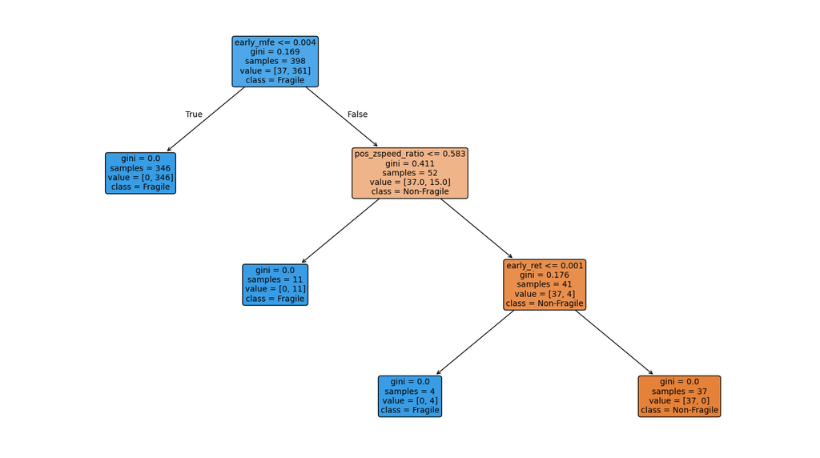

```python
plt.figure(figsize=(18, 10))
plot_tree(
    dt_model,
    feature_names=feature_names,
    class_names=["Non-Fragile", "Fragile"],
    filled=True,
    rounded=True,
    fontsize=10,
    max_depth=3   # 🔥 clave para que sea legible
)
plt.show()
```

## Conclusión

En este estudio se evaluó un conjunto amplio de modelos de clasificación binaria sobre un dataset tabular pequeño y altamente desbalanceado, utilizando una estrategia de validación cruzada estratificada y la métrica **F1-macro** como criterio principal de comparación. Los modelos analizados incluyeron métodos basados en distancia, modelos lineales, clasificadores probabilísticos, árboles de decisión, ensambles, máquinas de soporte vectorial y redes neuronales.

Este resultado sugiere que la estructura subyacente de los datos está dominada por **reglas claras y umbrales bien definidos**, que pueden ser capturados de forma eficiente por modelos basados en particiones del espacio de características. En un contexto con **pocas variables, tamaño muestral reducido y señal predictiva fuerte**, los árboles de decisión presentan una ventaja clara al ofrecer un equilibrio adecuado entre sesgo y varianza, evitando la sobre-regularización que puede introducirse al utilizar modelos más complejos.

Asimismo, el uso de **F1-macro** como métrica de evaluación permitió asegurar un desempeño balanceado entre clases, penalizando explícitamente modelos que favorecen la clase mayoritaria. En este sentido, el árbol de decisión demostró una capacidad robusta para discriminar correctamente ambas clases, incluso bajo condiciones de fuerte desbalance.

En conclusión, los resultados obtenidos refuerzan la idea de que **modelos simples y explicables pueden superar a enfoques más sofisticados cuando la señal del problema está bien definida**, lo que convierte al árbol de decisión en una opción especialmente adecuada tanto para despliegue en producción como para análisis interpretables en entornos de investigación.